# Data and Analyes for ‘Bad bankers no more? Truth-telling and (dis)honesty in the finance industry’

Christoph Huber, Juergen Huber

# Intro

This file contains R-code to replicate all analyses, tables, and figures in ‘*Bad bankers no more? Truth-telling and (dis)honesty in the finance industry*’.

The experiments were run between November 2018 and January 2020 with oTree by Chen et al. (2016). All analyses were conducted in R.

Required R-packages:

```r
library(plyr)
library(tidyverse)
library(readxl)
library(wesanderson)
library(ggthemes)
library(kableExtra)
library(stargazer)
library(lfe)
library(viridis)
library(car)
library(Rmisc)
```

First, we import, tidy, reshape, and merge the raw data files from the experiment (see below).  
**To skip this step**, load the following `.RData`-files and go to section *Analysis*:

```r
load("_norms_before.RData")
load("_norms_stud.RData")
load("_norms_studprof.RData")
load("_tt_before.RData")
load("_tt_pf.RData")
load("_tt_stud.RData")
load("_tt.RData")
load("_norms.RData")
load("_reshaped.RData")
load("_reshaped_norms.RData")
load("_merge.RData")
```

# Data preparation

## Import and tidy data

The following commands import the raw experiment output from folder `_raw` as an `.xlsx`-file into R, converts it into a tibble, and tidies and organises all relevant variables.

### Import and tidy data from STUD

```r
csv <- read_xlsx("_raw/data_students1/all_apps_wide_2018-12-14.xlsx")
csv1 <- read.csv("_raw/data_students2fin/all_apps_wide_2020-01-17.csv")
csv2 <- read.csv("_raw/data_students2neu/all_apps_wide_2020-01-17.csv")
csv3 <- read.csv("_raw/data_students2abs/all_apps_wide_2020-01-17.csv")

data <- tbl_df(csv)
data <- data %>% rbind.fill(csv1, csv2, csv3)

tt_stud <- data %>%
  filter((session.code == "6vi3dw2b"|session.code == "9auk5aea"|session.code=="7q355nra"|session.code == "s1pa9lws"|session.code == "9d565pyp"|session.code == "o75chhp9"), participant._index_in_pages>=11)

tt_stud <- tt_stud %>%
  rename(session = session.code,
         context = tt.1.player.context,
         treatment = tt.1.player.treatment,
         subject = participant.code,
         choice1 = tt.1.player.choice_1,
         choice2 = tt.1.player.choice_2,
         choice3 = tt.1.player.choice_3,
         choice4 = tt.1.player.choice_4,
         choice5 = tt.1.player.choice_5,
         belief1 = tt.1.player.belief_1,
         belief2 = tt.1.player.belief_2,
         belief3 = tt.1.player.belief_3,
         belief4 = tt.1.player.belief_4,
         belief5 = tt.1.player.belief_5,
         order = tt.1.player.order,
         severity = tt.1.player.severity,
         reputation = tt.1.player.reputation,
         pref1_1 = postexp.1.player.pref1_1,
         pref1_2 = postexp.1.player.pref1_2,
         pref1_3 = postexp.1.player.pref1_3,
         pref1_4 = postexp.1.player.pref1_4,
         pref2_1 = postexp.1.player.pref2_1,
         pref2_2 = postexp.1.player.pref2_2,
         pref2_3 = postexp.1.player.pref2_3,
         risk = postexp.1.player.risk_aversion1,
         age = postexp.1.player.age,
         female = postexp.1.player.female,
         education = postexp.1.player.education,
         job = postexp.1.player.jobfunction,
         investment = postexp.1.player.investment,
         whichinvestment = postexp.1.player.whichinvestment,
         payoff = participant.payoff) %>%
  mutate(tt = 1,
         word1 = paste0(wordscra.1.player.word1_1,
                        wordscra.1.player.word1_2,
                        wordscra.1.player.word1_3,
                        wordscra.1.player.word1_4,
                        wordscra.1.player.word1_5),
         word2 = paste0(wordscra.1.player.word2_1,
                        wordscra.1.player.word2_2,
                        wordscra.1.player.word2_3),
         word3 = paste0(wordscra.1.player.word3_1,
                        wordscra.1.player.word3_2,
                        wordscra.1.player.word3_3,
                        wordscra.1.player.word3_4,
                        wordscra.1.player.word3_5,
                        wordscra.1.player.word3_6),
         word4 = paste0(wordscra.1.player.word4_1,
                        wordscra.1.player.word4_2,
                        wordscra.1.player.word4_3,
                        wordscra.1.player.word4_4,
                        wordscra.1.player.word4_5),
         word5 = paste0(wordscra.1.player.word5_1,
                        wordscra.1.player.word5_2,
                        wordscra.1.player.word5_3,
                        wordscra.1.player.word5_4,
                        wordscra.1.player.word5_5),
         word6 = paste0(wordscra.1.player.word6_1,
                        wordscra.1.player.word6_2,
                        wordscra.1.player.word6_3,
                        wordscra.1.player.word6_4),
         word1f = ifelse(word1 == tools::toTitleCase(tolower("stock")), 1, 0),
         word3f = ifelse(word3 == tools::toTitleCase(tolower("broker")), 1, 0),
         word4f = ifelse(word4 == tools::toTitleCase(tolower("money")), 1, 0),
         word6f = ifelse(word6 == tools::toTitleCase(tolower("bond")), 1, 0),
         wordsf = word1f + word3f + word4f + word6f,
         lies = choice1 + choice2 + choice3 + choice4 + choice5,
         beliefs = belief1/100 + belief2/100 + belief3/100 + belief4/100 + belief5/100
         ) %>%
  select(-starts_with("participant."),
         -starts_with("session."),
         -starts_with("postexp"),
         -starts_with("tt."),
         -starts_with("tt_norms."),
         -starts_with("bt."),
         -starts_with("wordscra.")) %>%
  arrange(session, context, subject) %>%
  group_by(context)

norms_stud <- data %>%
  filter((session.code == "f7hlbgua"|session.code == "r8k3mqov"|session.code=="23zy7355")
         & participant._index_in_pages==27)

norms_stud <- norms_stud %>%
  rename(session = session.code,
         context = tt_norms.1.player.context,
         subject = participant.code,
         norms_true1 = tt_norms.1.player.norm_true,
         norms_true2 = tt_norms.2.player.norm_true,
         norms_true3 = tt_norms.3.player.norm_true,
         norms_true4 = tt_norms.4.player.norm_true,
         norms_true5 = tt_norms.5.player.norm_true,
         norms_false1 = tt_norms.1.player.norm_false,
         norms_false2 = tt_norms.2.player.norm_false,
         norms_false3 = tt_norms.3.player.norm_false,
         norms_false4 = tt_norms.4.player.norm_false,
         norms_false5 = tt_norms.5.player.norm_false,
         belief1 = tt_norms.5.player.belief_1,
         belief2 = tt_norms.5.player.belief_2,
         belief3 = tt_norms.5.player.belief_3,
         belief4 = tt_norms.5.player.belief_4,
         belief5 = tt_norms.5.player.belief_5,
         order = tt_norms.1.player.order,
         pref1_1 = postexp.1.player.pref1_1,
         pref1_2 = postexp.1.player.pref1_2,
         pref1_3 = postexp.1.player.pref1_3,
         pref1_4 = postexp.1.player.pref1_4,
         pref2_1 = postexp.1.player.pref2_1,
         pref2_2 = postexp.1.player.pref2_2,
         pref2_3 = postexp.1.player.pref2_3,
         risk = postexp.1.player.risk_aversion1,
         age = postexp.1.player.age,
         female = postexp.1.player.female,
         education = postexp.1.player.education,
         job = postexp.1.player.jobfunction,
         investment = postexp.1.player.investment,
         whichinvestment = postexp.1.player.whichinvestment) %>%
  mutate(tt = 0,
         word1 = paste0(wordscra.1.player.word1_1,
                        wordscra.1.player.word1_2,
                        wordscra.1.player.word1_3,
                        wordscra.1.player.word1_4,
                        wordscra.1.player.word1_5),
         word2 = paste0(wordscra.1.player.word2_1,
                        wordscra.1.player.word2_2,
                        wordscra.1.player.word2_3),
         word3 = paste0(wordscra.1.player.word3_1,
                        wordscra.1.player.word3_2,
                        wordscra.1.player.word3_3,
                        wordscra.1.player.word3_4,
                        wordscra.1.player.word3_5,
                        wordscra.1.player.word3_6),
         word4 = paste0(wordscra.1.player.word4_1,
                        wordscra.1.player.word4_2,
                        wordscra.1.player.word4_3,
                        wordscra.1.player.word4_4,
                        wordscra.1.player.word4_5),
         word5 = paste0(wordscra.1.player.word5_1,
                        wordscra.1.player.word5_2,
                        wordscra.1.player.word5_3,
                        wordscra.1.player.word5_4,
                        wordscra.1.player.word5_5),
         word6 = paste0(wordscra.1.player.word6_1,
                        wordscra.1.player.word6_2,
                        wordscra.1.player.word6_3,
                        wordscra.1.player.word6_4),
         word1f = ifelse(word1 == tools::toTitleCase(tolower("stock")), 1, 0),
         word3f = ifelse(word3 == tools::toTitleCase(tolower("broker")), 1, 0),
         word4f = ifelse(word4 == tools::toTitleCase(tolower("money")), 1, 0),
         word6f = ifelse(word6 == tools::toTitleCase(tolower("bond")), 1, 0),
         wordsf = word1f + word3f + word4f + word6f,
         beliefs = belief1/100 + belief2/100 + belief3/100 + belief4/100 + belief5/100
         ) %>%
  select(-starts_with("participant."),
         -starts_with("session."),
         -starts_with("postexp"),
         -starts_with("tt_norms."),
         -starts_with("tt."),
         -starts_with("bt."),
         -starts_with("wordscra.")) %>%
  arrange(session, context, subject) %>%
  group_by(context)

norms_stud <- norms_stud %>%
  mutate(norms_false1 = (norms_false1-3.5) / 2.5,
         norms_false2 = (norms_false2-3.5) / 2.5,
         norms_false3 = (norms_false3-3.5) / 2.5,
         norms_false4 = (norms_false4-3.5) / 2.5,
         norms_false5 = (norms_false5-3.5) / 2.5,
         norms_true1 = (norms_true1-3.5) / 2.5,
         norms_true2 = (norms_true2-3.5) / 2.5,
         norms_true3 = (norms_true3-3.5) / 2.5,
         norms_true4 = (norms_true4-3.5) / 2.5,
         norms_true5 = (norms_true5-3.5) / 2.5,
         norms_false = (norms_false1 + norms_false2 + norms_false3 + norms_false4)/4,
         norms_true = (norms_true1 + norms_true2 + norms_true3 + norms_true4)/4)

save(tt_stud, file="_tt_stud.RData")
save(norms_stud, file="_norms_stud.RData")
```

### Import and tidy data from PROF (before.world)

```r
csv <- read.csv("_raw/data_before/all_apps_wide_2019-02-27.csv")
data <- tbl_df(csv)

tt_before <- data %>%
  filter((session.code == "sl4o33w2")
         & participant._index_in_pages==12)

tt_before <- tt_before %>%
  rename(session = session.code,
         context = tt.1.player.context,
         subject = participant.code,
         choice1 = tt.1.player.choice_1,
         choice2 = tt.1.player.choice_2,
         choice3 = tt.1.player.choice_3,
         choice4 = tt.1.player.choice_4,
         choice5 = tt.1.player.choice_5,
         belief1 = tt.1.player.belief_1,
         belief2 = tt.1.player.belief_2,
         belief3 = tt.1.player.belief_3,
         belief4 = tt.1.player.belief_4,
         belief5 = tt.1.player.belief_5,
         order = tt.1.player.order,
         pref1_1 = postexp.1.player.pref1_1,
         pref1_2 = postexp.1.player.pref1_2,
         pref1_3 = postexp.1.player.pref1_3,
         pref1_4 = postexp.1.player.pref1_4,
         pref2_1 = postexp.1.player.pref2_1,
         pref2_2 = postexp.1.player.pref2_2,
         pref2_3 = postexp.1.player.pref2_3,
         risk = postexp.1.player.risk_aversion1,
         age = postexp.1.player.age,
         female = postexp.1.player.female,
         education = postexp.1.player.education,
         job = postexp.1.player.jobfunction,
         investment = postexp.1.player.investment,
         whichinvestment = postexp.1.player.whichinvestment,
         finnews = postexp.1.player.finnews,
         payoff = participant.payoff) %>%
  mutate(tt = 1,
         word1 = paste0(wordscra.1.player.word1_1,
                        wordscra.1.player.word1_2,
                        wordscra.1.player.word1_3,
                        wordscra.1.player.word1_4,
                        wordscra.1.player.word1_5),
         word2 = paste0(wordscra.1.player.word2_1,
                        wordscra.1.player.word2_2,
                        wordscra.1.player.word2_3),
         word3 = paste0(wordscra.1.player.word3_1,
                        wordscra.1.player.word3_2,
                        wordscra.1.player.word3_3,
                        wordscra.1.player.word3_4,
                        wordscra.1.player.word3_5,
                        wordscra.1.player.word3_6),
         word4 = paste0(wordscra.1.player.word4_1,
                        wordscra.1.player.word4_2,
                        wordscra.1.player.word4_3,
                        wordscra.1.player.word4_4,
                        wordscra.1.player.word4_5),
         word5 = paste0(wordscra.1.player.word5_1,
                        wordscra.1.player.word5_2,
                        wordscra.1.player.word5_3,
                        wordscra.1.player.word5_4,
                        wordscra.1.player.word5_5),
         word6 = paste0(wordscra.1.player.word6_1,
                        wordscra.1.player.word6_2,
                        wordscra.1.player.word6_3,
                        wordscra.1.player.word6_4),
         word1f = ifelse(word1 == tools::toTitleCase(tolower("stock")), 1, 0),
         word3f = ifelse(word3 == tools::toTitleCase(tolower("broker")), 1, 0),
         word4f = ifelse(word4 == tools::toTitleCase(tolower("money")), 1, 0),
         word6f = ifelse(word6 == tools::toTitleCase(tolower("bond")), 1, 0),
         wordsf = word1f + word3f + word4f + word6f,
         lies = choice1 + choice2 + choice3 + choice4 + choice5,
         beliefs = belief1/100 + belief2/100 + belief3/100 + belief4/100 + belief5/100
  ) %>%
  select(-starts_with("participant."),
         -starts_with("session."),
         -starts_with("postexp"),
         -starts_with("tt."),
         -starts_with("tt_norms."),
         -starts_with("bt."),
         -starts_with("wordscra."),
         -starts_with("redirect.")) %>%
  arrange(session, context, subject) %>%
  group_by(context)

norms_before <- data %>%
  filter((session.code == "jzmo442c")
         & participant._index_in_pages==28)

norms_before <- norms_before %>%
  rename(session = session.code,
         context = tt_norms.1.player.context,
         subject = participant.code,
         norms_true1 = tt_norms.1.player.norm_true,
         norms_true2 = tt_norms.2.player.norm_true,
         norms_true3 = tt_norms.3.player.norm_true,
         norms_true4 = tt_norms.4.player.norm_true,
         norms_true5 = tt_norms.5.player.norm_true,
         norms_false1 = tt_norms.1.player.norm_false,
         norms_false2 = tt_norms.2.player.norm_false,
         norms_false3 = tt_norms.3.player.norm_false,
         norms_false4 = tt_norms.4.player.norm_false,
         norms_false5 = tt_norms.5.player.norm_false,
         belief1 = tt_norms.5.player.belief_1,
         belief2 = tt_norms.5.player.belief_2,
         belief3 = tt_norms.5.player.belief_3,
         belief4 = tt_norms.5.player.belief_4,
         belief5 = tt_norms.5.player.belief_5,
         order = tt_norms.1.player.order,
         pref1_1 = postexp.1.player.pref1_1,
         pref1_2 = postexp.1.player.pref1_2,
         pref1_3 = postexp.1.player.pref1_3,
         pref1_4 = postexp.1.player.pref1_4,
         pref2_1 = postexp.1.player.pref2_1,
         pref2_2 = postexp.1.player.pref2_2,
         pref2_3 = postexp.1.player.pref2_3,
         risk = postexp.1.player.risk_aversion1,
         age = postexp.1.player.age,
         female = postexp.1.player.female,
         education = postexp.1.player.education,
         job = postexp.1.player.jobfunction,
         investment = postexp.1.player.investment,
         whichinvestment = postexp.1.player.whichinvestment,
         finnews = postexp.1.player.finnews) %>%
  mutate(tt = 0,
         word1 = paste0(wordscra.1.player.word1_1,
                        wordscra.1.player.word1_2,
                        wordscra.1.player.word1_3,
                        wordscra.1.player.word1_4,
                        wordscra.1.player.word1_5),
         word2 = paste0(wordscra.1.player.word2_1,
                        wordscra.1.player.word2_2,
                        wordscra.1.player.word2_3),
         word3 = paste0(wordscra.1.player.word3_1,
                        wordscra.1.player.word3_2,
                        wordscra.1.player.word3_3,
                        wordscra.1.player.word3_4,
                        wordscra.1.player.word3_5,
                        wordscra.1.player.word3_6),
         word4 = paste0(wordscra.1.player.word4_1,
                        wordscra.1.player.word4_2,
                        wordscra.1.player.word4_3,
                        wordscra.1.player.word4_4,
                        wordscra.1.player.word4_5),
         word5 = paste0(wordscra.1.player.word5_1,
                        wordscra.1.player.word5_2,
                        wordscra.1.player.word5_3,
                        wordscra.1.player.word5_4,
                        wordscra.1.player.word5_5),
         word6 = paste0(wordscra.1.player.word6_1,
                        wordscra.1.player.word6_2,
                        wordscra.1.player.word6_3,
                        wordscra.1.player.word6_4),
         word1f = ifelse(word1 == tools::toTitleCase(tolower("stock")), 1, 0),
         word3f = ifelse(word3 == tools::toTitleCase(tolower("broker")), 1, 0),
         word4f = ifelse(word4 == tools::toTitleCase(tolower("money")), 1, 0),
         word6f = ifelse(word6 == tools::toTitleCase(tolower("bond")), 1, 0),
         wordsf = word1f + word3f + word4f + word6f,
         beliefs = belief1/100 + belief2/100 + belief3/100 + belief4/100 + belief5/100
  ) %>%
  select(-starts_with("participant."),
         -starts_with("session."),
         -starts_with("postexp"),
         -starts_with("tt_norms."),
         -starts_with("tt."),
         -starts_with("bt."),
         -starts_with("wordscra."),
         -starts_with("redirect.")) %>%
  arrange(session, context, subject) %>%
  group_by(context)

norms_before <- norms_before %>%
  mutate(norms_false1 = (norms_false1-3.5) / 2.5,
         norms_false2 = (norms_false2-3.5) / 2.5,
         norms_false3 = (norms_false3-3.5) / 2.5,
         norms_false4 = (norms_false4-3.5) / 2.5,
         norms_false5 = (norms_false5-3.5) / 2.5,
         norms_true1 = (norms_true1-3.5) / 2.5,
         norms_true2 = (norms_true2-3.5) / 2.5,
         norms_true3 = (norms_true3-3.5) / 2.5,
         norms_true4 = (norms_true4-3.5) / 2.5,
         norms_true5 = (norms_true5-3.5) / 2.5,
         norms_false = (norms_false1 + norms_false2 + norms_false3 + norms_false4)/4,
         norms_true = (norms_true1 + norms_true2 + norms_true3 + norms_true4)/4)

save(tt_before, file="_tt_before.RData")
save(norms_before, file="_norms_before.RData")
```

### Import and tidy data from STUDPROF.

```r
csv <- read_xlsx("_raw/data_studprof/all_apps_wide_2019-04-15.xlsx")

data <- tbl_df(csv)

norms_studprof <- data %>%
  filter((session.code == "7v1jo4vk")
         & participant._index_in_pages==27)

norms_studprof <- norms_studprof %>%
  rename(session = session.code,
         context = tt_norms.1.player.context,
         subject = participant.code,
         norms_true1 = tt_norms.1.player.norm_true,
         norms_true2 = tt_norms.2.player.norm_true,
         norms_true3 = tt_norms.3.player.norm_true,
         norms_true4 = tt_norms.4.player.norm_true,
         norms_true5 = tt_norms.5.player.norm_true,
         norms_false1 = tt_norms.1.player.norm_false,
         norms_false2 = tt_norms.2.player.norm_false,
         norms_false3 = tt_norms.3.player.norm_false,
         norms_false4 = tt_norms.4.player.norm_false,
         norms_false5 = tt_norms.5.player.norm_false,
         belief1 = tt_norms.5.player.belief_1,
         belief2 = tt_norms.5.player.belief_2,
         belief3 = tt_norms.5.player.belief_3,
         belief4 = tt_norms.5.player.belief_4,
         belief5 = tt_norms.5.player.belief_5,
         order = tt_norms.1.player.order,
         pref1_1 = postexp.1.player.pref1_1,
         pref1_2 = postexp.1.player.pref1_2,
         pref1_3 = postexp.1.player.pref1_3,
         pref1_4 = postexp.1.player.pref1_4,
         pref2_1 = postexp.1.player.pref2_1,
         pref2_2 = postexp.1.player.pref2_2,
         pref2_3 = postexp.1.player.pref2_3,
         risk = postexp.1.player.risk_aversion1,
         age = postexp.1.player.age,
         female = postexp.1.player.female,
         education = postexp.1.player.education,
         job = postexp.1.player.jobfunction,
         investment = postexp.1.player.investment,
         whichinvestment = postexp.1.player.whichinvestment) %>%
  mutate(tt = 0,
         word1 = paste0(wordscra.1.player.word1_1,
                        wordscra.1.player.word1_2,
                        wordscra.1.player.word1_3,
                        wordscra.1.player.word1_4,
                        wordscra.1.player.word1_5),
         word2 = paste0(wordscra.1.player.word2_1,
                        wordscra.1.player.word2_2,
                        wordscra.1.player.word2_3),
         word3 = paste0(wordscra.1.player.word3_1,
                        wordscra.1.player.word3_2,
                        wordscra.1.player.word3_3,
                        wordscra.1.player.word3_4,
                        wordscra.1.player.word3_5,
                        wordscra.1.player.word3_6),
         word4 = paste0(wordscra.1.player.word4_1,
                        wordscra.1.player.word4_2,
                        wordscra.1.player.word4_3,
                        wordscra.1.player.word4_4,
                        wordscra.1.player.word4_5),
         word5 = paste0(wordscra.1.player.word5_1,
                        wordscra.1.player.word5_2,
                        wordscra.1.player.word5_3,
                        wordscra.1.player.word5_4,
                        wordscra.1.player.word5_5),
         word6 = paste0(wordscra.1.player.word6_1,
                        wordscra.1.player.word6_2,
                        wordscra.1.player.word6_3,
                        wordscra.1.player.word6_4),
         word1f = ifelse(word1 == tools::toTitleCase(tolower("stock")), 1, 0),
         word3f = ifelse(word3 == tools::toTitleCase(tolower("broker")), 1, 0),
         word4f = ifelse(word4 == tools::toTitleCase(tolower("money")), 1, 0),
         word6f = ifelse(word6 == tools::toTitleCase(tolower("bond")), 1, 0),
         wordsf = word1f + word3f + word4f + word6f,
         beliefs = belief1/100 + belief2/100 + belief3/100 + belief4/100 + belief5/100
         ) %>%
  select(-starts_with("participant."),
         -starts_with("session."),
         -starts_with("postexp"),
         -starts_with("tt_norms."),
         -starts_with("tt."),
         -starts_with("bt."),
         -starts_with("wordscra.")) %>%
  arrange(session, context, subject) %>%
  group_by(context)

norms_studprof <- norms_studprof %>%
  mutate(norms_false1 = (norms_false1-3.5) / 2.5,
         norms_false2 = (norms_false2-3.5) / 2.5,
         norms_false3 = (norms_false3-3.5) / 2.5,
         norms_false4 = (norms_false4-3.5) / 2.5,
         norms_false5 = (norms_false5-3.5) / 2.5,
         norms_true1 = (norms_true1-3.5) / 2.5,
         norms_true2 = (norms_true2-3.5) / 2.5,
         norms_true3 = (norms_true3-3.5) / 2.5,
         norms_true4 = (norms_true4-3.5) / 2.5,
         norms_true5 = (norms_true5-3.5) / 2.5,
         norms_false = (norms_false1 + norms_false2 + norms_false3 + norms_false4)/4,
         norms_true = (norms_true1 + norms_true2 + norms_true3 + norms_true4)/4)

save(norms_studprof, file="_norms_studprof.RData")
```

### Import and tidy data from PROLIFIC

```r
csv <- read.csv("_raw/data_prolific/all_apps_wide_2020-01-08.csv")
csv1 <- read.csv("_raw/data_prolific/all_apps_wide_2020-01-14.csv")
csv2 <- read.csv("_raw/data_prolific/all_apps_wide_2020-01-17.csv")

data <- rbind(csv, csv1, csv2) %>% tbl_df()

exp <- read.csv("_raw/data_prolific/prolific_export_5e1478086e8aaba68ddcfa31.csv") %>%
  rename(participant.label = participant_id,
         age.prolific = age)

data <- left_join(data, exp,
                  by=c("participant.label"))

tt_pf <- data %>%
  filter((session.code == "cfs9uxep"|session.code == "t3qqecpo"|session.code == "b7rrvg7s")
         & participant._index_in_pages==12)

tt_pf <- tt_pf %>%
  rename(session = session.code,
         context = tt.1.player.context,
         treatment = tt.1.player.treatment,
         subject = participant.code,
         choice1 = tt.1.player.choice_1,
         choice2 = tt.1.player.choice_2,
         choice3 = tt.1.player.choice_3,
         choice4 = tt.1.player.choice_4,
         choice5 = tt.1.player.choice_5,
         belief1 = tt.1.player.belief_1,
         belief2 = tt.1.player.belief_2,
         belief3 = tt.1.player.belief_3,
         belief4 = tt.1.player.belief_4,
         belief5 = tt.1.player.belief_5,
         order = tt.1.player.order,
         severity = tt.1.player.severity,
         reputation = tt.1.player.reputation,
         pref1_1 = postexp.1.player.pref1_1,
         pref1_2 = postexp.1.player.pref1_2,
         pref1_3 = postexp.1.player.pref1_3,
         pref1_4 = postexp.1.player.pref1_4,
         pref2_1 = postexp.1.player.pref2_1,
         pref2_2 = postexp.1.player.pref2_2,
         pref2_3 = postexp.1.player.pref2_3,
         risk = postexp.1.player.risk_aversion1,
         age = postexp.1.player.age,
         female = postexp.1.player.female,
         education = postexp.1.player.education,
         job = postexp.1.player.jobfunction,
         investment = postexp.1.player.investment,
         whichinvestment = postexp.1.player.whichinvestment,
         finnews = postexp.1.player.finnews,
         payoff = participant.payoff) %>%
  mutate(tt = 1,
         word1 = paste0(wordscra.1.player.word1_1,
                        wordscra.1.player.word1_2,
                        wordscra.1.player.word1_3,
                        wordscra.1.player.word1_4,
                        wordscra.1.player.word1_5),
         word2 = paste0(wordscra.1.player.word2_1,
                        wordscra.1.player.word2_2,
                        wordscra.1.player.word2_3),
         word3 = paste0(wordscra.1.player.word3_1,
                        wordscra.1.player.word3_2,
                        wordscra.1.player.word3_3,
                        wordscra.1.player.word3_4,
                        wordscra.1.player.word3_5,
                        wordscra.1.player.word3_6),
         word4 = paste0(wordscra.1.player.word4_1,
                        wordscra.1.player.word4_2,
                        wordscra.1.player.word4_3,
                        wordscra.1.player.word4_4,
                        wordscra.1.player.word4_5),
         word5 = paste0(wordscra.1.player.word5_1,
                        wordscra.1.player.word5_2,
                        wordscra.1.player.word5_3,
                        wordscra.1.player.word5_4,
                        wordscra.1.player.word5_5),
         word6 = paste0(wordscra.1.player.word6_1,
                        wordscra.1.player.word6_2,
                        wordscra.1.player.word6_3,
                        wordscra.1.player.word6_4),
         word1f = ifelse(word1 == tools::toTitleCase(tolower("stock")), 1, 0),
         word3f = ifelse(word3 == tools::toTitleCase(tolower("broker")), 1, 0),
         word4f = ifelse(word4 == tools::toTitleCase(tolower("money")), 1, 0),
         word6f = ifelse(word6 == tools::toTitleCase(tolower("bond")), 1, 0),
         wordsf = word1f + word3f + word4f + word6f,
         lies = choice1 + choice2 + choice3 + choice4 + choice5,
         beliefs = belief1/100 + belief2/100 + belief3/100 + belief4/100 + belief5/100
  ) %>%
  select(-starts_with("participant."),
         -starts_with("session."),
         -starts_with("postexp"),
         -starts_with("tt."),
         -starts_with("tt_norms."),
         -starts_with("bt."),
         -starts_with("wordscra."),
         -starts_with("redirect.")) %>%
  arrange(session, context, subject) %>%
  group_by(context)

save(tt_pf, file="_tt_pf.RData")
```

## Reshape and merge

### Reshape data

```r
tt_stud_reshaped <- tt_stud %>%
  gather(cost, choice, choice1:choice5, belief1:belief5)
tt_stud_reshaped <- tt_stud_reshaped %>%
  extract(cost, c("question", "cost"), "(choice|belief)(.)")%>%
  mutate(
    treatment = ifelse(context == "financial", "sh_sev_fin",
                       ifelse(context == "neutral", "su_ha_neu",
                              "su_ha_abs")))

tt_before_reshaped <- tt_before %>%
  gather(cost, choice, choice1:choice5, belief1:belief5)
tt_before_reshaped <- tt_before_reshaped %>%
  extract(cost, c("question", "cost"), "(choice|belief)(.)")%>%
  mutate(
    treatment = ifelse(context == "financial", "sh_sev_fin",
                       ifelse(context == "neutral", "su_ha_neu",
                              "su_ha_abs")))

tt_pf_reshaped <- tt_pf %>%
  gather(cost, choice, choice1:choice5, belief1:belief5)
tt_pf_reshaped <- tt_pf_reshaped %>%
  extract(cost, c("question", "cost"), "(choice|belief)(.)") %>%
  mutate(
    treatment = ifelse(is.na(treatment),
                       ifelse(context == "financial", "sh_sev_fin",
                              ifelse(context == "neutral", "su_ha_neu",
                                     ifelse(context == "abstract", "su_ha_abs", context))),
                       as.character(treatment))
    )
```

### Merge STUD and PROF data

```r
tt_before$prof <- rep(1, nrow(tt_before))
norms_before$prof <- rep(1, nrow(norms_before))
tt_stud$prof <- rep(0, nrow(tt_stud))
norms_stud$prof <- rep(0, nrow(norms_stud))
norms_studprof$prof <- rep(2, nrow(norms_studprof))
tt_pf$prof <- rep(3, nrow(tt_pf))

tt_before$prof1 <- rep(1, nrow(tt_before))
norms_before$prof1 <- rep(1, nrow(norms_before))
tt_stud$prof1 <- rep(0, nrow(tt_stud))
norms_stud$prof1 <- rep(0, nrow(norms_stud))
norms_studprof$prof1 <- rep(0, nrow(norms_studprof))
tt_pf$prof1 <- rep(1, nrow(tt_pf))

tt_stud <- tt_stud %>%
  mutate(
    treatment = ifelse(is.na(treatment),
                       ifelse(context == "financial", "sh_sev_fin",
                              ifelse(context == "neutral", "su_ha_neu",
                                     ifelse(context == "abstract", "su_ha_abs",
context))),
                       as.character(treatment))
    )
tt_stud$treatment <- factor(tt_stud$treatment)


tt <- rbind(tt_before, tt_stud, tt_pf)
norms <- rbind(norms_before, norms_stud, norms_studprof)

tt <- tt %>%
  mutate(
    treatment = ifelse(is.na(treatment),
                       ifelse(context == "financial", "sh_sev_fin",
                              ifelse(context == "neutral", "su_ha_neu",
                                     ifelse(context == "abstract", "su_ha_abs", context))),
                       as.character(treatment))
    )
tt$treatment <- factor(tt$treatment)

norms <- norms %>%
  mutate(
    treatment = ifelse(context == "financial", "sh_sev_fin",
                       ifelse(context == "neutral", "su_ha_neu",
                              ifelse(context == "abstract", "su_ha_abs", context))),
    treatment)
norms$treatment <- factor(norms$treatment)


tt <- tt %>%
  mutate(
    job1 = ifelse(job == 0, "Portfolio Manager",
                           ifelse(job == 1, "Research Analyst",
                                  ifelse(job == 2, "Consultant",
                                         ifelse(job == 3, "Financial Advisor",
                                                ifelse(job == 4, "Chief-Level Executive",
                                                       ifelse(job == 5, "Trader",
                                                              ifelse(job == 6, "Fund Manager",
                                                                     ifelse(job == 7, "Investment Managent",
                                                                            "Other"))))))))
  )

norms <- norms %>%
  mutate(
    job1 = ifelse(job == 0, "Portfolio Manager",
                           ifelse(job == 1, "Research Analyst",
                                  ifelse(job == 2, "Consultant",
                                         ifelse(job == 3, "Financial Advisor",
                                                ifelse(job == 4, "Chief-Level Executive",
                                                       ifelse(job == 5, "Trader",
                                                              ifelse(job == 6, "Fund Manager",
                                                                     ifelse(job == 7, "Investment Managent",
                                                                            "Other"))))))))
  )


save(tt, file = "_tt.RData")
save(norms, file = "_norms.RData")
```

### Reshape pooled tt and norms

TT

```r
reshaped <- tt %>%
  gather(cost, choice, choice1:choice5, belief1:belief5)
reshaped <- reshaped %>%
  extract(cost, c("question", "cost"), "(choice|belief)(.)")
reshaped <- reshaped %>%
  spread(question, choice)

reshaped$belief <- reshaped$belief/100
reshaped$cost <- as.numeric(reshaped$cost) * (-1) + 5

save(reshaped, file = "_reshaped.RData")
```

Norms

```r
reshaped_norms <- norms %>%
  select(-norms_false, -norms_true) %>%
  gather(cost, choice, norms_true1:norms_false5, norms_false1:norms_false5, belief1:belief5)
reshaped_norms <- reshaped_norms %>%
  extract(cost, c("question", "cost"), "(norms_false|norms_true|belief)(.)")
reshaped_norms <- reshaped_norms %>%
  spread(question, choice) %>%
  mutate(norms = (norms_true + norms_false)/2)

reshaped_norms$belief <- reshaped_norms$belief/100
reshaped_norms$cost <- as.numeric(reshaped_norms$cost) * (-1) + 5

save(reshaped_norms, file = "_reshaped_norms.RData")
```

### Merge

```r
reshaped$treatment1 <- factor(reshaped$treatment,
                              levels = c('sh_sev_fin',
                                         'sh_ha_fin',
                                         'su_ha_neu',
                                         'su_sev_fin',
                                         'su_ha_abs',
                                         'su_ha_fin'))

reshaped_norms$treatment1 <- factor(reshaped_norms$treatment,
                              levels = c('sh_sev_fin',
                                         'sh_ha_fin',
                                         'su_ha_neu',
                                         'su_sev_fin',
                                         'su_ha_abs',
                                         'su_ha_fin'))

merge <- left_join(reshaped,
                   reshaped_norms %>%
                     group_by(prof, treatment1, cost) %>%
                     summarise(norms_false = mean(norms_false),
                               norms_true = mean(norms_true),
                               norms_belief = mean(belief),
                               prof1 = mean(prof1)) %>%
                     na.omit(),
                   by=c("treatment1", "cost"),
                   suffix = c(".tt", ".norms")) %>%
  filter(!is.na(prof.norms))

merge <- merge %>% mutate(norm = ifelse(choice==0, norms_true, norms_false))

save(merge, file = "_merge.RData")
```

# Analysis

## Table 2

```r
tt %>%
  group_by(prof1, treatment) %>%
  summarise(Pct = 1 - mean(lies, na.rm=TRUE)/5,
            sd = sd(lies/5, na.rm=TRUE),
            n = n()) %>%
  pivot_wider(names_from = prof1,
              values_from = c(Pct, sd, n)) %>%
  select(treatment,
         Pct_1, sd_1, n_1,
         Pct_0, sd_0, n_0)
```

| treatment | Pct_1 | sd_1 | n_1 | Pct_0 | sd_0 | n_0 |
| --- | --- | --- | --- | --- | --- | --- |
| sh_sev_fin | 0.6623656 | 0.3501285 | 93 | 0.3228070 | 0.2228208 | 57 |
| su_ha_abs | 0.4295082 | 0.3518258 | 61 | 0.2945455 | 0.2336650 | 55 |
| su_ha_neu | 0.6000000 | 0.3343123 | 69 | 0.3555556 | 0.2898709 | 54 |
| sh_ha_fin | 0.6298507 | 0.4018951 | 67 | NA | NA | NA |
| su_ha_fin | 0.7027027 | 0.3491567 | 74 | NA | NA | NA |
| su_sev_fin | 0.6627451 | 0.3588653 | 51 | NA | NA | NA |

```r
NA
```

Fisher’s exact tests for differences between treatments and subject pools in Table 2

```r
fisher.test(t(tt %>%
                filter(treatment == "su_ha_abs") %>%
                mutate(truths = 5 - lies) %>%
                group_by(prof1) %>%
                summarise(lies = sum(lies), truths = sum(truths)) %>%
                drop_na() %>%
                ungroup() %>%
                select(lies, truths)))
```

```
    Fisher's Exact Test for Count Data

data:  t(tt %>% filter(treatment == "su_ha_abs") %>% mutate(truths = 5 - lies) %>% group_by(prof1) %>% summarise(lies = sum(lies), truths = sum(truths)) %>% drop_na() %>% ungroup() %>% select(lies, truths))
p-value = 0.0007707
alternative hypothesis: true odds ratio is not equal to 1
95 percent confidence interval:
 1.259839 2.584840
sample estimates:
odds ratio
  1.801363
```

```r
fisher.test(tt %>%
    filter(treatment == "su_ha_abs") %>%
    mutate(truths = 5 - lies) %>%
    group_by(prof1, truths) %>%
    summarise(n = n()) %>%
    pivot_wider(names_from = prof1, values_from = n) %>%
    select(`0`, `1`) %>%
    mutate(`0` = ifelse(is.na(`0`), 0, `0`)))
```

```
    Fisher's Exact Test for Count Data

data:  tt %>% filter(treatment == "su_ha_abs") %>% mutate(truths = 5 - lies) %>% group_by(prof1, truths) %>% summarise(n = n()) %>% pivot_wider(names_from = prof1, values_from = n) %>% select(`0`, `1`) %>% mutate(`0` = ifelse(is.na(`0`), 0, `0`))
p-value = 0.01988
alternative hypothesis: two.sided
```

```r
fisher.test(t(tt %>%
                filter(treatment == "su_ha_neu") %>%
                mutate(truths = 5 - lies) %>%
                group_by(prof1) %>%
                summarise(lies = sum(lies), truths = sum(truths)) %>%
                drop_na() %>%
                ungroup() %>%
                select(lies, truths)))
```

```
    Fisher's Exact Test for Count Data

data:  t(tt %>% filter(treatment == "su_ha_neu") %>% mutate(truths = 5 - lies) %>% group_by(prof1) %>% summarise(lies = sum(lies), truths = sum(truths)) %>% drop_na() %>% ungroup() %>% select(lies, truths))
p-value = 1.666e-09
alternative hypothesis: true odds ratio is not equal to 1
95 percent confidence interval:
 1.930016 3.832415
sample estimates:
odds ratio
   2.71397
```

```r
fisher.test(t(tt %>%
                filter(treatment == "sh_sev_fin") %>%
                mutate(truths = 5 - lies) %>%
                group_by(prof1) %>%
                summarise(lies = sum(lies), truths = sum(truths)) %>%
                drop_na() %>%
                ungroup() %>%
                select(lies, truths)))
```

```
    Fisher's Exact Test for Count Data

data:  t(tt %>% filter(treatment == "sh_sev_fin") %>% mutate(truths = 5 - lies) %>% group_by(prof1) %>% summarise(lies = sum(lies), truths = sum(truths)) %>% drop_na() %>% ungroup() %>% select(lies, truths))
p-value < 2.2e-16
alternative hypothesis: true odds ratio is not equal to 1
95 percent confidence interval:
 2.970967 5.708049
sample estimates:
odds ratio
  4.106707
```

```r
fisher.test(t(tt %>%
                filter(treatment == "su_ha_abs" | treatment == "su_ha_neu",
                     prof1 == 1) %>%
                mutate(truths = 5 - lies) %>%
                group_by(treatment) %>%
                summarise(lies = sum(lies), truths = sum(truths)) %>%
                drop_na() %>%
                ungroup() %>%
                select(lies, truths)))
```

```
    Fisher's Exact Test for Count Data

data:  t(tt %>% filter(treatment == "su_ha_abs" | treatment == "su_ha_neu", prof1 == 1) %>% mutate(truths = 5 - lies) %>% group_by(treatment) %>% summarise(lies = sum(lies), truths = sum(truths)) %>% drop_na() %>% ungroup() %>% select(lies, truths))
p-value = 1.508e-05
alternative hypothesis: true odds ratio is not equal to 1
95 percent confidence interval:
 1.439713 2.757502
sample estimates:
odds ratio
  1.990223
```

```r
fisher.test(t(tt %>%
                filter(treatment == "su_ha_neu" | treatment == "sh_sev_fin",
                     prof1 == 1) %>%
                mutate(truths = 5 - lies) %>%
                group_by(treatment) %>%
                summarise(lies = sum(lies), truths = sum(truths)) %>%
                drop_na() %>%
                ungroup() %>%
                select(lies, truths)))
```

```
    Fisher's Exact Test for Count Data

data:  t(tt %>% filter(treatment == "su_ha_neu" | treatment == "sh_sev_fin", prof1 == 1) %>% mutate(truths = 5 - lies) %>% group_by(treatment) %>% summarise(lies = sum(lies), truths = sum(truths)) %>% drop_na() %>% ungroup() %>% select(lies, truths))
p-value = 0.07638
alternative hypothesis: true odds ratio is not equal to 1
95 percent confidence interval:
 0.5670733 1.0316256
sample estimates:
odds ratio
 0.7648775
```

```r
fisher.test(t(tt %>%
                filter(treatment == "su_ha_neu" | treatment == "sh_ha_fin",
                     prof1 == 1) %>%
                mutate(truths = 5 - lies) %>%
                group_by(treatment) %>%
                summarise(lies = sum(lies), truths = sum(truths)) %>%
                drop_na() %>%
                ungroup() %>%
                select(lies, truths)))
```

```
    Fisher's Exact Test for Count Data

data:  t(tt %>% filter(treatment == "su_ha_neu" | treatment == "sh_ha_fin", prof1 == 1) %>% mutate(truths = 5 - lies) %>% group_by(treatment) %>% summarise(lies = sum(lies), truths = sum(truths)) %>% drop_na() %>% ungroup() %>% select(lies, truths))
p-value = 0.4317
alternative hypothesis: true odds ratio is not equal to 1
95 percent confidence interval:
 0.6392648 1.2152731
sample estimates:
odds ratio
 0.8816817
```

```r
fisher.test(t(tt %>%
                filter(treatment == "su_ha_neu" | treatment == "su_ha_fin",
                     prof1 == 1) %>%
                mutate(truths = 5 - lies) %>%
                group_by(treatment) %>%
                summarise(lies = sum(lies), truths = sum(truths)) %>%
                drop_na() %>%
                ungroup() %>%
                select(lies, truths)))
```

```
    Fisher's Exact Test for Count Data

data:  t(tt %>% filter(treatment == "su_ha_neu" | treatment == "su_ha_fin", prof1 == 1) %>% mutate(truths = 5 - lies) %>% group_by(treatment) %>% summarise(lies = sum(lies), truths = sum(truths)) %>% drop_na() %>% ungroup() %>% select(lies, truths))
p-value = 0.004618
alternative hypothesis: true odds ratio is not equal to 1
95 percent confidence interval:
 0.4597632 0.8756031
sample estimates:
odds ratio
 0.6350387
```

```r
fisher.test(t(tt %>%
                filter(treatment == "su_ha_neu" | treatment == "su_sev_fin",
                     prof1 == 1) %>%
                mutate(truths = 5 - lies) %>%
                group_by(treatment) %>%
                summarise(lies = sum(lies), truths = sum(truths)) %>%
                drop_na() %>%
                ungroup() %>%
                select(lies, truths)))
```

```
    Fisher's Exact Test for Count Data

data:  t(tt %>% filter(treatment == "su_ha_neu" | treatment == "su_sev_fin", prof1 == 1) %>% mutate(truths = 5 - lies) %>% group_by(treatment) %>% summarise(lies = sum(lies), truths = sum(truths)) %>% drop_na() %>% ungroup() %>% select(lies, truths))
p-value = 0.1248
alternative hypothesis: true odds ratio is not equal to 1
95 percent confidence interval:
 0.922487 1.863805
sample estimates:
odds ratio
   1.30948
```

```r
fisher.test(t(tt %>%
                filter(treatment == "su_ha_abs" | treatment == "sh_sev_fin",
                     prof1 == 1) %>%
                mutate(truths = 5 - lies) %>%
                group_by(treatment) %>%
                summarise(lies = sum(lies), truths = sum(truths)) %>%
                drop_na() %>%
                ungroup() %>%
                select(lies, truths)))
```

```
    Fisher's Exact Test for Count Data

data:  t(tt %>% filter(treatment == "su_ha_abs" | treatment == "sh_sev_fin", prof1 == 1) %>% mutate(truths = 5 - lies) %>% group_by(treatment) %>% summarise(lies = sum(lies), truths = sum(truths)) %>% drop_na() %>% ungroup() %>% select(lies, truths))
p-value = 2.099e-10
alternative hypothesis: true odds ratio is not equal to 1
95 percent confidence interval:
 0.2819450 0.5223579
sample estimates:
odds ratio
 0.3842967
```

```r
fisher.test(t(tt %>%
                filter(treatment == "su_ha_abs" | treatment == "sh_ha_fin",
                     prof1 == 1) %>%
                mutate(truths = 5 - lies) %>%
                group_by(treatment) %>%
                summarise(lies = sum(lies), truths = sum(truths)) %>%
                drop_na() %>%
                ungroup() %>%
                select(lies, truths)))
```

```
    Fisher's Exact Test for Count Data

data:  t(tt %>% filter(treatment == "su_ha_abs" | treatment == "sh_ha_fin", prof1 == 1) %>% mutate(truths = 5 - lies) %>% group_by(treatment) %>% summarise(lies = sum(lies), truths = sum(truths)) %>% drop_na() %>% ungroup() %>% select(lies, truths))
p-value = 5.328e-07
alternative hypothesis: true odds ratio is not equal to 1
95 percent confidence interval:
 0.3181272 0.6152152
sample estimates:
odds ratio
  0.443027
```

```r
fisher.test(t(tt %>%
                filter(treatment == "su_ha_abs" | treatment == "su_ha_fin",
                     prof1 == 1) %>%
                mutate(truths = 5 - lies) %>%
                group_by(treatment) %>%
                summarise(lies = sum(lies), truths = sum(truths)) %>%
                drop_na() %>%
                ungroup() %>%
                select(lies, truths)))
```

```
    Fisher's Exact Test for Count Data

data:  t(tt %>% filter(treatment == "su_ha_abs" | treatment == "su_ha_fin", prof1 == 1) %>% mutate(truths = 5 - lies) %>% group_by(treatment) %>% summarise(lies = sum(lies), truths = sum(truths)) %>% drop_na() %>% ungroup() %>% select(lies, truths))
p-value = 7.975e-13
alternative hypothesis: true odds ratio is not equal to 1
95 percent confidence interval:
 2.255993 4.370244
sample estimates:
odds ratio
  3.133817
```

```r
fisher.test(t(tt %>%
                filter(treatment == "su_ha_abs" | treatment == "su_sev_fin",
                     prof1 == 1) %>%
                mutate(truths = 5 - lies) %>%
                group_by(treatment) %>%
                summarise(lies = sum(lies), truths = sum(truths)) %>%
                drop_na() %>%
                ungroup() %>%
                select(lies, truths)))
```

```
    Fisher's Exact Test for Count Data

data:  t(tt %>% filter(treatment == "su_ha_abs" | treatment == "su_sev_fin", prof1 == 1) %>% mutate(truths = 5 - lies) %>% group_by(treatment) %>% summarise(lies = sum(lies), truths = sum(truths)) %>% drop_na() %>% ungroup() %>% select(lies, truths))
p-value = 4.524e-08
alternative hypothesis: true odds ratio is not equal to 1
95 percent confidence interval:
 1.822846 3.741251
sample estimates:
odds ratio
  2.605537
```

```r
fisher.test(t(tt %>%
                filter((treatment == "su_ha_abs" & prof1 == 0) |
                        (treatment == "sh_ha_fin" & prof1 == 1)) %>%
                mutate(truths = 5 - lies) %>%
                group_by(prof1) %>%
                summarise(lies = sum(lies), truths = sum(truths)) %>%
                drop_na() %>%
                ungroup() %>%
                select(lies, truths)))
```

```
    Fisher's Exact Test for Count Data

data:  t(tt %>% filter((treatment == "su_ha_abs" & prof1 == 0) | (treatment == "sh_ha_fin" & prof1 == 1)) %>% mutate(truths = 5 - lies) %>% group_by(prof1) %>% summarise(lies = sum(lies), truths = sum(truths)) %>% drop_na() %>% ungroup() %>% select(lies, truths))
p-value < 2.2e-16
alternative hypothesis: true odds ratio is not equal to 1
95 percent confidence interval:
 2.857242 5.819375
sample estimates:
odds ratio
  4.064949
```

```r
fisher.test(t(tt %>%
                filter((treatment == "su_ha_abs" & prof1 == 0) |
                        (treatment == "su_ha_fin" & prof1 == 1)) %>%
                mutate(truths = 5 - lies) %>%
                group_by(prof1) %>%
                summarise(lies = sum(lies), truths = sum(truths)) %>%
                drop_na() %>%
                ungroup() %>%
                select(lies, truths)))
```

```
    Fisher's Exact Test for Count Data

data:  t(tt %>% filter((treatment == "su_ha_abs" & prof1 == 0) | (treatment == "su_ha_fin" & prof1 == 1)) %>% mutate(truths = 5 - lies) %>% group_by(prof1) %>% summarise(lies = sum(lies), truths = sum(truths)) %>% drop_na() %>% ungroup() %>% select(lies, truths))
p-value < 2.2e-16
alternative hypothesis: true odds ratio is not equal to 1
95 percent confidence interval:
 3.965084 8.090910
sample estimates:
odds ratio
  5.643898
```

```r
fisher.test(t(tt %>%
                filter((treatment == "su_ha_abs" & prof1 == 0) |
                        (treatment == "su_sev_fin" & prof1 == 1)) %>%
                mutate(truths = 5 - lies) %>%
                group_by(prof1) %>%
                summarise(lies = sum(lies), truths = sum(truths)) %>%
                drop_na() %>%
                ungroup() %>%
                select(lies, truths)))
```

```
    Fisher's Exact Test for Count Data

data:  t(tt %>% filter((treatment == "su_ha_abs" & prof1 == 0) | (treatment == "su_sev_fin" & prof1 == 1)) %>% mutate(truths = 5 - lies) %>% group_by(prof1) %>% summarise(lies = sum(lies), truths = sum(truths)) %>% drop_na() %>% ungroup() %>% select(lies, truths))
p-value < 2.2e-16
alternative hypothesis: true odds ratio is not equal to 1
95 percent confidence interval:
 3.208177 6.909541
sample estimates:
odds ratio
  4.691418
```

```r
fisher.test(t(tt %>%
                filter((treatment == "su_ha_neu" & prof1 == 0) |
                        (treatment == "sh_ha_fin" & prof1 == 1)) %>%
                mutate(truths = 5 - lies) %>%
                group_by(prof1) %>%
                summarise(lies = sum(lies), truths = sum(truths)) %>%
                drop_na() %>%
                ungroup() %>%
                select(lies, truths)))
```

```
    Fisher's Exact Test for Count Data

data:  t(tt %>% filter((treatment == "su_ha_neu" & prof1 == 0) | (treatment == "sh_ha_fin" & prof1 == 1)) %>% mutate(truths = 5 - lies) %>% group_by(prof1) %>% summarise(lies = sum(lies), truths = sum(truths)) %>% drop_na() %>% ungroup() %>% select(lies, truths))
p-value = 2.601e-11
alternative hypothesis: true odds ratio is not equal to 1
95 percent confidence interval:
 2.179459 4.367056
sample estimates:
odds ratio
  3.078125
```

```r
fisher.test(t(tt %>%
                filter((treatment == "su_ha_neu" & prof1 == 0) |
                        (treatment == "su_ha_fin" & prof1 == 1)) %>%
                mutate(truths = 5 - lies) %>%
                group_by(prof1) %>%
                summarise(lies = sum(lies), truths = sum(truths)) %>%
                drop_na() %>%
                ungroup() %>%
                select(lies, truths)))
```

```
    Fisher's Exact Test for Count Data

data:  t(tt %>% filter((treatment == "su_ha_neu" & prof1 == 0) | (treatment == "su_ha_fin" & prof1 == 1)) %>% mutate(truths = 5 - lies) %>% group_by(prof1) %>% summarise(lies = sum(lies), truths = sum(truths)) %>% drop_na() %>% ungroup() %>% select(lies, truths))
p-value < 2.2e-16
alternative hypothesis: true odds ratio is not equal to 1
95 percent confidence interval:
 3.024817 6.070014
sample estimates:
odds ratio
  4.273418
```

```r
fisher.test(t(tt %>%
                filter((treatment == "su_ha_neu" & prof1 == 0) |
                        (treatment == "su_sev_fin" & prof1 == 1)) %>%
                mutate(truths = 5 - lies) %>%
                group_by(prof1) %>%
                summarise(lies = sum(lies), truths = sum(truths)) %>%
                drop_na() %>%
                ungroup() %>%
                select(lies, truths)))
```

```
    Fisher's Exact Test for Count Data

data:  t(tt %>% filter((treatment == "su_ha_neu" & prof1 == 0) | (treatment == "su_sev_fin" & prof1 == 1)) %>% mutate(truths = 5 - lies) %>% group_by(prof1) %>% summarise(lies = sum(lies), truths = sum(truths)) %>% drop_na() %>% ungroup() %>% select(lies, truths))
p-value = 1.975e-12
alternative hypothesis: true odds ratio is not equal to 1
95 percent confidence interval:
 2.446300 5.189032
sample estimates:
odds ratio
   3.55228
```

```r
fisher.test(t(tt %>%
                filter((treatment == "sh_sev_fin" & prof1 == 0) |
                        (treatment == "sh_ha_fin" & prof1 == 1)) %>%
                mutate(truths = 5 - lies) %>%
                group_by(prof1) %>%
                summarise(lies = sum(lies), truths = sum(truths)) %>%
                drop_na() %>%
                ungroup() %>%
                select(lies, truths)))
```

```
    Fisher's Exact Test for Count Data

data:  t(tt %>% filter((treatment == "sh_sev_fin" & prof1 == 0) | (treatment == "sh_ha_fin" & prof1 == 1)) %>% mutate(truths = 5 - lies) %>% group_by(prof1) %>% summarise(lies = sum(lies), truths = sum(truths)) %>% drop_na() %>% ungroup() %>% select(lies, truths))
p-value = 2.276e-14
alternative hypothesis: true odds ratio is not equal to 1
95 percent confidence interval:
 2.524411 5.051531
sample estimates:
odds ratio
  3.561745
```

```r
fisher.test(t(tt %>%
                filter((treatment == "sh_sev_fin" & prof1 == 0) |
                        (treatment == "su_ha_fin" & prof1 == 1)) %>%
                mutate(truths = 5 - lies) %>%
                group_by(prof1) %>%
                summarise(lies = sum(lies), truths = sum(truths)) %>%
                drop_na() %>%
                ungroup() %>%
                select(lies, truths)))
```

```
    Fisher's Exact Test for Count Data

data:  t(tt %>% filter((treatment == "sh_sev_fin" & prof1 == 0) | (treatment == "su_ha_fin" & prof1 == 1)) %>% mutate(truths = 5 - lies) %>% group_by(prof1) %>% summarise(lies = sum(lies), truths = sum(truths)) %>% drop_na() %>% ungroup() %>% select(lies, truths))
p-value < 2.2e-16
alternative hypothesis: true odds ratio is not equal to 1
95 percent confidence interval:
 3.503829 7.022560
sample estimates:
odds ratio
  4.945024
```

```r
fisher.test(t(tt %>%
                filter((treatment == "sh_sev_fin" & prof1 == 0) |
                        (treatment == "su_sev_fin" & prof1 == 1)) %>%
                mutate(truths = 5 - lies) %>%
                group_by(prof1) %>%
                summarise(lies = sum(lies), truths = sum(truths)) %>%
                drop_na() %>%
                ungroup() %>%
                select(lies, truths)))
```

```
    Fisher's Exact Test for Count Data

data:  t(tt %>% filter((treatment == "sh_sev_fin" & prof1 == 0) | (treatment == "su_sev_fin" & prof1 == 1)) %>% mutate(truths = 5 - lies) %>% group_by(prof1) %>% summarise(lies = sum(lies), truths = sum(truths)) %>% drop_na() %>% ungroup() %>% select(lies, truths))
p-value = 2.421e-15
alternative hypothesis: true odds ratio is not equal to 1
95 percent confidence interval:
 2.833528 6.001503
sample estimates:
odds ratio
  4.110742
```

Wilcoxon rank sum tests for differences between treatments and subject pools in Table 2

```r
wilcox.test(lies ~ treatment,
            data = tt %>%
              filter(treatment == "su_ha_abs" | treatment == "su_ha_neu",
                     prof1 == 1)
            )
```

```
    Wilcoxon rank sum test with continuity correction

data:  lies by treatment
W = 2685, p-value = 0.005688
alternative hypothesis: true location shift is not equal to 0
```

```r
wilcox.test(lies ~ treatment,
            data = tt %>%
              filter(treatment == "su_ha_abs" | treatment == "sh_sev_fin",
                     prof1 == 1)
            )
```

```
    Wilcoxon rank sum test with continuity correction

data:  lies by treatment
W = 1843.5, p-value = 0.0001608
alternative hypothesis: true location shift is not equal to 0
```

```r
wilcox.test(lies ~ treatment,
            data = tt %>%
              filter(treatment == "su_ha_neu" | treatment == "sh_sev_fin",
                     prof1 == 1)
            )
```

```
    Wilcoxon rank sum test with continuity correction

data:  lies by treatment
W = 2884, p-value = 0.2537
alternative hypothesis: true location shift is not equal to 0
```

```r
wilcox.test(lies ~ treatment,
            data = tt %>%
              filter(treatment == "su_ha_abs" | treatment == "su_ha_fin",
                     prof1 == 1)
            )
```

```
    Wilcoxon rank sum test with continuity correction

data:  lies by treatment
W = 3172, p-value = 2.857e-05
alternative hypothesis: true location shift is not equal to 0
```

```r
wilcox.test(lies ~ treatment,
            data = tt %>%
              filter(treatment == "su_ha_neu" | treatment == "su_sev_fin",
                     prof1 == 1)
            )
```

```
    Wilcoxon rank sum test with continuity correction

data:  lies by treatment
W = 1958.5, p-value = 0.2743
alternative hypothesis: true location shift is not equal to 0
```

```r
wilcox.test(lies ~ treatment,
            data = tt %>%
              filter(treatment == "su_ha_neu" | treatment == "sh_ha_fin",
                     prof1 == 1)
            )
```

```
    Wilcoxon rank sum test with continuity correction

data:  lies by treatment
W = 2178, p-value = 0.5466
alternative hypothesis: true location shift is not equal to 0
```

```r
wilcox.test(lies ~ treatment,
            data = tt %>%
              filter(treatment == "su_ha_neu" | treatment == "su_ha_fin",
                     prof1 == 1)
            )
```

```
    Wilcoxon rank sum test with continuity correction

data:  lies by treatment
W = 2119.5, p-value = 0.06654
alternative hypothesis: true location shift is not equal to 0
```

```r
wilcox.test(lies ~ prof1,
            data = tt %>%
              filter(treatment == "su_ha_abs")
            )
```

```
    Wilcoxon rank sum test with continuity correction

data:  lies by prof1
W = 1993, p-value = 0.0743
alternative hypothesis: true location shift is not equal to 0
```

```r
wilcox.test(lies ~ prof1,
            data = tt %>%
              filter(treatment == "su_ha_neu")
            )
```

```
    Wilcoxon rank sum test with continuity correction

data:  lies by prof1
W = 2634.5, p-value = 5.874e-05
alternative hypothesis: true location shift is not equal to 0
```

```r
wilcox.test(lies ~ prof1,
            data = tt %>%
              filter(treatment == "sh_sev_fin")
            )
```

```
    Wilcoxon rank sum test with continuity correction

data:  lies by prof1
W = 4060, p-value = 2.265e-08
alternative hypothesis: true location shift is not equal to 0
```

```r
wilcox.test(lies ~ prof1,
            data = tt %>%
              filter((treatment == "su_ha_abs" & prof1 == 0) |
                        (treatment == "sh_ha_fin" & prof1 == 1))
            )
```

```
    Wilcoxon rank sum test with continuity correction

data:  lies by prof1
W = 2702, p-value = 6.15e-06
alternative hypothesis: true location shift is not equal to 0
```

```r
wilcox.test(lies ~ prof1,
            data = tt %>%
              filter((treatment == "su_ha_abs" & prof1 == 0) |
                        (treatment == "su_ha_fin" & prof1 == 1))
            )
```

```
    Wilcoxon rank sum test with continuity correction

data:  lies by prof1
W = 3278.5, p-value = 1.314e-09
alternative hypothesis: true location shift is not equal to 0
```

```r
wilcox.test(lies ~ prof1,
            data = tt %>%
              filter((treatment == "su_ha_abs" & prof1 == 0) |
                        (treatment == "su_sev_fin" & prof1 == 1))
            )
```

```
    Wilcoxon rank sum test with continuity correction

data:  lies by prof1
W = 2195.5, p-value = 3.088e-07
alternative hypothesis: true location shift is not equal to 0
```

```r
wilcox.test(lies ~ prof1,
            data = tt %>%
              filter((treatment == "su_ha_neu" & prof1 == 0) |
                        (treatment == "sh_ha_fin" & prof1 == 1))
            )
```

```
    Wilcoxon rank sum test with continuity correction

data:  lies by prof1
W = 2498.5, p-value = 0.0002264
alternative hypothesis: true location shift is not equal to 0
```

```r
wilcox.test(lies ~ prof1,
            data = tt %>%
              filter((treatment == "su_ha_neu" & prof1 == 0) |
                        (treatment == "su_ha_fin" & prof1 == 1))
            )
```

```
    Wilcoxon rank sum test with continuity correction

data:  lies by prof1
W = 3054, p-value = 1.457e-07
alternative hypothesis: true location shift is not equal to 0
```

```r
wilcox.test(lies ~ prof1,
            data = tt %>%
              filter((treatment == "su_ha_neu" & prof1 == 0) |
                        (treatment == "su_sev_fin" & prof1 == 1))
            )
```

```
    Wilcoxon rank sum test with continuity correction

data:  lies by prof1
W = 2033.5, p-value = 1.721e-05
alternative hypothesis: true location shift is not equal to 0
```

```r
wilcox.test(lies ~ prof1,
            data = tt %>%
              filter((treatment == "sh_sev_fin" & prof1 == 0) |
                        (treatment == "sh_ha_fin" & prof1 == 1))
            )
```

```
    Wilcoxon rank sum test with continuity correction

data:  lies by prof1
W = 2721.5, p-value = 3.108e-05
alternative hypothesis: true location shift is not equal to 0
```

```r
wilcox.test(lies ~ prof1,
            data = tt %>%
              filter((treatment == "sh_sev_fin" & prof1 == 0) |
                        (treatment == "su_ha_fin" & prof1 == 1))
            )
```

```
    Wilcoxon rank sum test with continuity correction

data:  lies by prof1
W = 3333.5, p-value = 4.986e-09
alternative hypothesis: true location shift is not equal to 0
```

```r
wilcox.test(lies ~ prof1,
            data = tt %>%
              filter((treatment == "sh_sev_fin" & prof1 == 0) |
                        (treatment == "su_sev_fin" & prof1 == 1))
            )
```

```
    Wilcoxon rank sum test with continuity correction

data:  lies by prof1
W = 2230, p-value = 1.066e-06
alternative hypothesis: true location shift is not equal to 0
```

Treatment differences in STUD

```r
# Wilcoxon rank sum test: abstract vs. neutral
wilcox.test(lies ~ treatment, data = tt %>% filter(prof1 == 0, treatment != "sh_sev_fin"))
```

```
    Wilcoxon rank sum test with continuity correction

data:  lies by treatment
W = 1607.5, p-value = 0.4467
alternative hypothesis: true location shift is not equal to 0
```

```r
# Wilcoxon rank sum test: abstract vs. financial
wilcox.test(lies ~ treatment, data = tt %>% filter(prof1 == 0, treatment != "su_ha_neu"))
```

```
    Wilcoxon rank sum test with continuity correction

data:  lies by treatment
W = 1474, p-value = 0.5755
alternative hypothesis: true location shift is not equal to 0
```

```r
# Wilcoxon rank sum test: neutral vs. financial
wilcox.test(lies ~ treatment, data = tt %>% filter(prof1 == 0, treatment != "su_ha_abs"))
```

```
    Wilcoxon rank sum test with continuity correction

data:  lies by treatment
W = 1569, p-value = 0.8564
alternative hypothesis: true location shift is not equal to 0
```

```r
# Kruskal-Wallis test
kruskal.test(lies ~ as.factor(treatment), data = tt %>% filter(prof1 == 0))
```

```
    Kruskal-Wallis rank sum test

data:  lies by as.factor(treatment)
Kruskal-Wallis chi-squared = 0.62287, df = 2, p-value = 0.7324
```

```r
# Fisher's exact test
test <- tt %>%
  filter(prof1 == 0) %>%
  mutate(truths = 5 - lies) %>%
  group_by(treatment) %>%
  summarise(lies = sum(lies), truths = sum(truths)) %>%
  drop_na() %>%
  ungroup() %>%
  select(lies, truths)
fisher.test(test)
```

```
    Fisher's Exact Test for Count Data

data:  test
p-value = 0.3128
alternative hypothesis: two.sided
```

```r
fisher.test(t(test))
```

```
    Fisher's Exact Test for Count Data

data:  t(test)
p-value = 0.3128
alternative hypothesis: two.sided
```

Treatment differences in STUD

```r
# Wilcoxon rank sum test: abstract vs. neutral
wilcox.test(lies ~ context, data = tt_stud %>% filter(context != "financial"))
```

```
    Wilcoxon rank sum test with continuity correction

data:  lies by context
W = 2009, p-value = 0.1185
alternative hypothesis: true location shift is not equal to 0
```

```r
# Wilcoxon rank sum test: abstract vs. financial
wilcox.test(lies ~ context, data = tt_stud %>% filter(context != "neutral"))
```

```
    Wilcoxon rank sum test with continuity correction

data:  lies by context
W = 2067, p-value = 0.06041
alternative hypothesis: true location shift is not equal to 0
```

```r
# Wilcoxon rank sum test: neutral vs. financial
wilcox.test(lies ~ context, data = tt_stud %>% filter(context != "abstract"))
```

```
    Wilcoxon rank sum test with continuity correction

data:  lies by context
W = 782, p-value = 0.8619
alternative hypothesis: true location shift is not equal to 0
```

```r
# Kruskal-Wallis test
kruskal.test(lies ~ as.factor(treatment), data = tt_stud)
```

```
    Kruskal-Wallis rank sum test

data:  lies by as.factor(treatment)
Kruskal-Wallis chi-squared = 0.62287, df = 2, p-value = 0.7324
```

Treatment differences in PROF

```r
# Wilcoxon rank sum test: abstract vs. neutral
wilcox.test(lies ~ treatment, data = tt %>%
              filter(prof1==1,
                     treatment == "su_ha_abs" | treatment == "su_ha_neu"))
```

```
    Wilcoxon rank sum test with continuity correction

data:  lies by treatment
W = 2685, p-value = 0.005688
alternative hypothesis: true location shift is not equal to 0
```

```r
# Wilcoxon rank sum test: abstract vs. financial
wilcox.test(lies ~ treatment, data = tt %>%
              filter(prof1==1,
                     treatment == "su_ha_abs" | treatment == "sh_sev_fin"))
```

```
    Wilcoxon rank sum test with continuity correction

data:  lies by treatment
W = 1843.5, p-value = 0.0001608
alternative hypothesis: true location shift is not equal to 0
```

```r
# Wilcoxon rank sum test: neutral vs. financial
wilcox.test(lies ~ treatment, data = tt %>%
              filter(prof1==1,
                     treatment == "sh_sev_fin" | treatment == "su_ha_neu"))
```

```
    Wilcoxon rank sum test with continuity correction

data:  lies by treatment
W = 2884, p-value = 0.2537
alternative hypothesis: true location shift is not equal to 0
```

## Table B1

```r
tt %>%
  group_by(prof, treatment) %>%
  summarise(Pct = 1 - mean(lies, na.rm=TRUE)/5,
            sd = sd(lies/5, na.rm=TRUE),
            n = n()) %>%
  pivot_wider(names_from = prof,
              values_from = c(Pct, sd, n)) %>%
  select(treatment,
         Pct_1, sd_1, n_1,
         Pct_3, sd_3, n_3,
         Pct_0, sd_0, n_0)
```

| treatment | Pct_1 | sd_1 | n_1 | Pct_3 | sd_3 | n_3 | Pct_0 | sd_0 | n_0 |
| --- | --- | --- | --- | --- | --- | --- | --- | --- | --- |
| sh_sev_fin | 0.6526316 | 0.3142876 | 38 | 0.6690909 | 0.3755848 | 55 | 0.3228070 | 0.2228208 | 57 |
| su_ha_abs | 0.3764706 | 0.3508076 | 34 | 0.4962963 | 0.3480511 | 27 | 0.2945455 | 0.2336650 | 55 |
| su_ha_neu | 0.5209302 | 0.3059397 | 43 | 0.7307692 | 0.3438246 | 26 | 0.3555556 | 0.2898709 | 54 |
| sh_ha_fin | NA | NA | NA | 0.6298507 | 0.4018951 | 67 | NA | NA | NA |
| su_ha_fin | NA | NA | NA | 0.7027027 | 0.3491567 | 74 | NA | NA | NA |
| su_sev_fin | NA | NA | NA | 0.6627451 | 0.3588653 | 51 | NA | NA | NA |

```r
NA
```

Wilcoxon rank sum tests for differences between subject pools in Table B1

```r
wilcox.test(lies ~ prof,
            data = tt %>% filter(treatment == "sh_sev_fin", prof > 0))
```

```
    Wilcoxon rank sum test with continuity correction

data:  lies by prof
W = 1091.5, p-value = 0.7054
alternative hypothesis: true location shift is not equal to 0
```

```r
wilcox.test(lies ~ prof,
            data = tt %>% filter(treatment == "su_ha_abs", prof > 0))
```

```
    Wilcoxon rank sum test with continuity correction

data:  lies by prof
W = 556.5, p-value = 0.1508
alternative hypothesis: true location shift is not equal to 0
```

```r
wilcox.test(lies ~ prof,
            data = tt %>% filter(treatment == "su_ha_neu", prof > 0))
```

```
    Wilcoxon rank sum test with continuity correction

data:  lies by prof
W = 751, p-value = 0.01455
alternative hypothesis: true location shift is not equal to 0
```

```r
wilcox.test(lies ~ prof,
            data = tt %>% filter(treatment == "sh_sev_fin", prof != 3))
```

```
    Wilcoxon rank sum test with continuity correction

data:  lies by prof
W = 1696, p-value = 1.795e-06
alternative hypothesis: true location shift is not equal to 0
```

```r
wilcox.test(lies ~ prof,
            data = tt %>% filter(treatment == "su_ha_abs", prof != 3))
```

```
    Wilcoxon rank sum test with continuity correction

data:  lies by prof
W = 1002, p-value = 0.5637
alternative hypothesis: true location shift is not equal to 0
```

```r
wilcox.test(lies ~ prof,
            data = tt %>% filter(treatment == "su_ha_neu", prof != 3))
```

```
    Wilcoxon rank sum test with continuity correction

data:  lies by prof
W = 1531.5, p-value = 0.005865
alternative hypothesis: true location shift is not equal to 0
```

```r
wilcox.test(lies ~ prof,
            data = tt %>% filter(treatment == "sh_sev_fin", prof != 1))
```

```
    Wilcoxon rank sum test with continuity correction

data:  lies by prof
W = 2364, p-value = 2.105e-06
alternative hypothesis: true location shift is not equal to 0
```

```r
wilcox.test(lies ~ prof,
            data = tt %>% filter(treatment == "su_ha_abs", prof != 1))
```

```
    Wilcoxon rank sum test with continuity correction

data:  lies by prof
W = 991, p-value = 0.01162
alternative hypothesis: true location shift is not equal to 0
```

```r
wilcox.test(lies ~ prof,
            data = tt %>% filter(treatment == "su_ha_neu", prof != 1))
```

```
    Wilcoxon rank sum test with continuity correction

data:  lies by prof
W = 1103, p-value = 2.45e-05
alternative hypothesis: true location shift is not equal to 0
```

## Table B9

Subject demographics

```r
demographics_prof0_mean <- tt %>%
  ungroup() %>%
  filter(prof == 0,
         age <= 100) %>%
  summarise(n = n(),
            risk = mean(risk),
            age = mean(age),
            female = mean(female),
            invest = mean(investment)) %>%
  pivot_longer(-n, names_to = "Variable", values_to = "Mean PROF0")

demographics_prof0_sd <- tt %>%
  ungroup() %>%
  filter(prof == 0,
         age <= 100) %>%
  summarise(n = n(),
            risk = sd(risk),
            age = sd(age),
            female = sd(female),
            invest = sd(investment)) %>%
  pivot_longer(-n, names_to = "Variable", values_to = "SD PROF0")

demographics_prof1_mean <- tt %>%
  ungroup() %>%
  filter(prof == 1) %>%
  summarise(n = n(),
            risk = mean(risk),
            age = mean(age),
            female = mean(female),
            invest = mean(investment)) %>%
  pivot_longer(-n, names_to = "Variable", values_to = "Mean PROF1")

demographics_prof1_sd <- tt %>%
  ungroup() %>%
  filter(prof == 1) %>%
  summarise(n = n(),
            risk = sd(risk),
            age = sd(age),
            female = sd(female),
            invest = sd(investment)) %>%
  pivot_longer(-n, names_to = "Variable", values_to = "SD PROF1")

demographics_prof3_mean <- tt %>%
  ungroup() %>%
  filter(prof == 3,
         age <= 100) %>%
  summarise(n = n(),
            risk = mean(risk),
            age = mean(age),
            female = mean(female),
            invest = mean(investment)) %>%
  pivot_longer(-n, names_to = "Variable", values_to = "Mean PROF3")

demographics_prof3_sd <- tt %>%
  ungroup() %>%
  filter(prof == 3,
         age <= 100) %>%
  summarise(n = n(),
            risk = sd(risk),
            age = sd(age),
            female = sd(female),
            invest = sd(investment)) %>%
  pivot_longer(-n, names_to = "Variable", values_to = "SD PROF3")

demographics_prof0norms_mean <- norms %>%
  ungroup() %>%
  filter(prof == 0,
         age <= 100) %>%
  summarise(n = n(),
            risk = mean(risk),
            age = mean(age),
            female = mean(female),
            invest = mean(investment)) %>%
  pivot_longer(-n, names_to = "Variable", values_to = "Mean PROF0norms")

demographics_prof0norms_sd <- norms %>%
  ungroup() %>%
  filter(prof == 0,
         age <= 100) %>%
  summarise(n = n(),
            risk = sd(risk),
            age = sd(age),
            female = sd(female),
            invest = sd(investment)) %>%
  pivot_longer(-n, names_to = "Variable", values_to = "SD PROF0norms")

demographics_prof1norms_mean <- norms %>%
  ungroup() %>%
  filter(prof == 1,
         age <= 100) %>%
  summarise(n = n(),
            risk = mean(risk),
            age = mean(age),
            female = mean(female),
            invest = mean(investment)) %>%
  pivot_longer(-n, names_to = "Variable", values_to = "Mean PROF1norms")

demographics_prof1norms_sd <- norms %>%
  ungroup() %>%
  filter(prof == 1,
         age <= 100) %>%
  summarise(n = n(),
            risk = sd(risk),
            age = sd(age),
            female = sd(female),
            invest = sd(investment)) %>%
  pivot_longer(-n, names_to = "Variable", values_to = "SD PROF1norms")

demographics_prof2norms_mean <- norms %>%
  ungroup() %>%
  filter(prof == 2,
         age <= 100) %>%
  summarise(n = n(),
            risk = mean(risk),
            age = mean(age),
            female = mean(female),
            invest = mean(investment)) %>%
  pivot_longer(-n, names_to = "Variable", values_to = "Mean PROF2norms")

demographics_prof2norms_sd <- norms %>%
  ungroup() %>%
  filter(prof == 2,
         age <= 100) %>%
  summarise(n = n(),
            risk = sd(risk),
            age = sd(age),
            female = sd(female),
            invest = sd(investment)) %>%
  pivot_longer(-n, names_to = "Variable", values_to = "SD PROF2norms")

demographics_prof <- demographics_prof1_mean %>%
  left_join(demographics_prof1_sd) %>%
  left_join(demographics_prof3_mean, by = c("Variable")) %>%
  left_join(demographics_prof3_sd, by = c("Variable")) %>%
  left_join(demographics_prof1norms_mean, by = c("Variable")) %>%
  left_join(demographics_prof1norms_sd, by = c("Variable")) %>%
  select(-starts_with("n"))

demographics_stud <- demographics_prof0_mean %>%
  left_join(demographics_prof0_sd) %>%
  left_join(demographics_prof0norms_mean, by = c("Variable")) %>%
  left_join(demographics_prof0norms_sd, by = c("Variable")) %>%
  left_join(demographics_prof2norms_mean, by = c("Variable")) %>%
  left_join(demographics_prof2norms_sd, by = c("Variable")) %>%
  select(-starts_with("n"))

demographics_prof %>%
  kable(format = "latex",
        booktabs = T,
        caption = "Demographics",
        digits = 3) %>%
  kable_styling(latex_options = c("hold_position"),
                full_width = T)
```

```r
demographics_stud %>%
  kable(format = "latex",
        booktabs = T,
        caption = "Demographics",
        digits = 3) %>%
  kable_styling(latex_options = c("hold_position"),
                full_width = T)
```

```r
NA
```

```r
tt_before %>%
  ungroup() %>%
  group_by(prof, education) %>%
  summarise(Prop = round(n()/115, 3))
```

| prof | education | Prop |
| --- | --- | --- |
| 1 | -1 | 0.009 |
| 1 | 0 | 0.009 |
| 1 | 2 | 0.017 |
| 1 | 3 | 0.096 |
| 1 | 4 | 0.870 |

```r
tt_pf %>%
  ungroup() %>%
  group_by(prof, education) %>%
  summarise(Prop = round(n()/300, 3))
```

| prof | education | Prop |
| --- | --- | --- |
| 3 | -1 | 0.010 |
| 3 | 0 | 0.010 |
| 3 | 1 | 0.017 |
| 3 | 2 | 0.077 |
| 3 | 3 | 0.150 |
| 3 | 4 | 0.737 |

```r
norms_before %>%
  ungroup() %>%
  group_by(prof, education) %>%
  summarise(Prop = round(n()/45, 3))
```

| prof | education | Prop |
| --- | --- | --- |
| 1 | -1 | 0.022 |
| 1 | 2 | 0.022 |
| 1 | 3 | 0.022 |
| 1 | 4 | 0.933 |

```r
tt_stud %>%
  ungroup() %>%
  group_by(education) %>%
  summarise(Prop = round(n()/166, 3))
```

| education | Prop |
| --- | --- |
| -1 | 0.012 |
| 0 | 0.006 |
| 2 | 0.024 |
| 3 | 0.518 |
| 4 | 0.440 |

```r
norms_stud %>%
  ungroup() %>%
  group_by(education) %>%
  summarise(Prop = round(n()/70, 3))
```

| education | Prop |
| --- | --- |
| -1 | 0.029 |
| 0 | 0.014 |
| 1 | 0.014 |
| 2 | 0.029 |
| 3 | 0.429 |
| 4 | 0.486 |

```r
tt %>%
  filter(prof==1) %>%
  ungroup() %>%
  group_by(job1) %>%
  summarise(Prop = round(n()/115, 3))
```

| job1 | Prop |
| --- | --- |
| Chief-Level Executive | 0.026 |
| Consultant | 0.104 |
| Financial Advisor | 0.157 |
| Fund Manager | 0.061 |
| Investment Managent | 0.087 |
| Other | 0.148 |
| Portfolio Manager | 0.191 |
| Research Analyst | 0.130 |
| Trader | 0.096 |

```r
tt %>%
  filter(prof==3) %>%
  ungroup() %>%
  group_by(job1) %>%
  summarise(Prop = round(n()/300, 3))
```

| job1 | Prop |
| --- | --- |
| Chief-Level Executive | 0.017 |
| Consultant | 0.090 |
| Financial Advisor | 0.137 |
| Fund Manager | 0.007 |
| Investment Managent | 0.023 |
| Other | 0.620 |
| Portfolio Manager | 0.027 |
| Research Analyst | 0.057 |
| Trader | 0.023 |

```r
norms %>%
  filter(prof==1) %>%
  ungroup() %>%
  group_by(job1) %>%
  summarise(Prop = round(n()/115, 3))
```

| job1 | Prop |
| --- | --- |
| Chief-Level Executive | 0.026 |
| Consultant | 0.035 |
| Financial Advisor | 0.052 |
| Fund Manager | 0.017 |
| Investment Managent | 0.070 |
| Other | 0.096 |
| Portfolio Manager | 0.061 |
| Research Analyst | 0.009 |
| Trader | 0.026 |

```r
NA
NA
```

## Figure 1

```r
tt_stud_reshaped$treatment1 <- factor(tt_stud_reshaped$treatment, levels = c('sh_sev_fin', 'su_ha_neu', 'su_ha_abs'))
options(repr.plot.width  = 8,
        repr.plot.height = 6)
ggplot(tt_stud_reshaped %>%
         filter(question=="choice") %>%
         mutate(cost = (as.numeric(cost) * (-1) + 5),
                choice = 100-choice*100) %>%
         group_by(cost, treatment1) %>%
         summarise(choice=mean(choice)),
       aes(x=cost, y=choice, group=treatment1,
           shape=treatment1, color=treatment1)) +
  geom_line(aes(color=treatment1, linetype=treatment1), size=2) +
  geom_point(lwd = 2.7) +
  labs(x="Economic cost of honesty",
       y="Percentage of honest reports") +
  theme_bw() +
  theme(text = element_text(size = 20)) +
  theme(legend.position="bottom",
        legend.key.width = unit(3, "line"),
        legend.title = element_blank(),
        panel.grid.minor.x = element_blank()) +
  scale_linetype_manual(guide = 'legend', name="Treatment",
                        values = c("solid",
                                   "dashed",
                                   "dotdash"),
                        labels = c(expression(FIN),
                                   expression(NEU),
                                   expression(ABS))) +
  scale_color_manual(guide = 'legend', name="Treatment",
                     values=viridis(n = 6)[c(1, 3, 5)],
                     labels = c(expression(FIN),
                                expression(NEU),
                                expression(ABS))) +
  scale_shape_discrete(guide="legend", name="Treatment",
                       labels = c(expression(FIN),
                                  expression(NEU),
                                  expression(ABS))) +
  ylim(0, 100) +
  labs(title = "STUD")
ggsave("../git_data/graphs/PercLies_STUD.pdf", width=20, height=15, units="cm")
```

```
1: Yes
2: No
```

[figure not shown]

```r
1
```

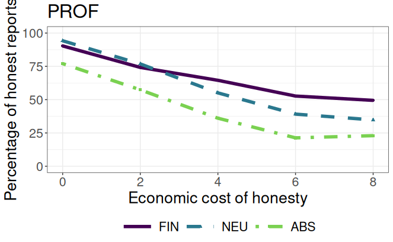

```r
tt_before_reshaped$treatment1 <- factor(tt_before_reshaped$treatment, levels = c('sh_sev_fin', 'su_ha_neu', 'su_ha_abs'))
tt_pf_reshaped$treatment1 <- factor(tt_pf_reshaped$treatment, levels = c('sh_sev_fin', 'su_ha_neu', 'su_ha_abs'))
options(repr.plot.width  = 8,
        repr.plot.height = 6)
ggplot(rbind(tt_before_reshaped, tt_pf_reshaped) %>%
         filter(question=="choice",
                treatment=="su_ha_neu"|treatment=="su_ha_abs"|treatment=="sh_sev_fin") %>%
         mutate(cost = ((as.numeric(cost) * (-1) + 5)*2),
                choice = 100 - choice*100) %>%
         group_by(cost, treatment1) %>%
         summarise(choice=mean(choice)),
       aes(x=cost, y=choice, group=treatment1,
           shape=treatment1, color=treatment1)) +
  geom_line(aes(color=treatment1, linetype=treatment1), size=2) +
  geom_point(lwd = 2.7) +
  labs(x="Economic cost of honesty",
       y="Percentage of honest reports") +
  theme_bw() +
  theme(text = element_text(size = 20)) +
  theme(legend.position="bottom",
        legend.key.width = unit(3, "line"),
        legend.title = element_blank(),
        panel.grid.minor.x = element_blank()) +
  scale_linetype_manual(guide = 'legend', name="Treatment",
                        values = c("solid",
                                   "dashed",
                                   "dotdash"),
                        labels = c(expression(FIN),
                                   expression(NEU),
                                   expression(ABS))) +
  scale_color_manual(guide = 'legend', name="Treatment",
                     values=viridis(n = 6)[c(1, 3, 5)],
                     labels = c(expression(FIN),
                                expression(NEU),
                                expression(ABS))) +
  scale_shape_discrete(guide="legend", name="Treatment",
                       labels = c(expression(FIN),
                                  expression(NEU),
                                  expression(ABS))) +
  ylim(0, 100) +
  labs(title = "PROF")
ggsave("../git_data/graphs/PercLies_PROF3treat.pdf", width=20, height=15, units="cm")
```

## Figure 2

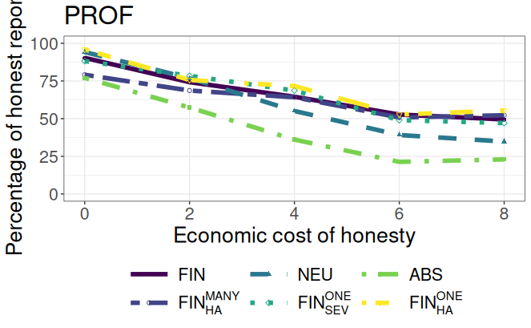

```r
tt_before_reshaped$treatment1 <- factor(tt_before_reshaped$treatment, levels = c('sh_sev_fin', 'sh_ha_fin', 'su_ha_neu',
                                                                         'su_sev_fin', 'su_ha_abs', 'su_ha_fin'))
tt_pf_reshaped$treatment1 <- factor(tt_pf_reshaped$treatment, levels = c('sh_sev_fin', 'sh_ha_fin', 'su_ha_neu',
                                                                         'su_sev_fin', 'su_ha_abs', 'su_ha_fin'))
options(repr.plot.width  = 8,
        repr.plot.height = 6)
ggplot(rbind(tt_before_reshaped, tt_pf_reshaped) %>%
         filter(question=="choice") %>%
         mutate(cost = (as.numeric(cost) * (-1) + 5) * 2,
                choice = 100 - choice*100) %>%
         group_by(cost, treatment1) %>%
         summarise(choice=mean(choice)),
       aes(x=cost, y=choice, group=treatment1,
           shape=treatment1, color=treatment1)) +
  geom_line(aes(color=treatment1, linetype=treatment1), size=2) +
  geom_point(lwd = 2.7) +
  labs(x="Economic cost of honesty",
       y="Percentage of honest reports") +
  theme_bw() +
  theme(text = element_text(size = 20)) +
  theme(legend.position="bottom",
        legend.key.width = unit(3, "line"),
        legend.title = element_blank(),
        panel.grid.minor.x = element_blank()) +
  scale_linetype_manual(guide = 'legend', name="Treatment",
                        values = c("solid",
                                   "twodash",
                                   "dashed",
                                   "dotted",
                                   "dotdash",
                                   "12345678"),
                        labels = c(expression(FIN),
                                   expression(FIN[HA]^MANY),
                                   expression(NEU),
                                   expression(FIN[SEV]^ONE),
                                   expression(ABS),
                                   expression(FIN[HA]^ONE))) +
  scale_color_manual(guide = 'legend', name="Treatment",
                     values=viridis(n = 6),
                     labels = c(expression(FIN),
                                expression(FIN[HA]^MANY),
                                expression(NEU),
                                expression(FIN[SEV]^ONE),
                                expression(ABS),
                                expression(FIN[HA]^ONE))) +
  scale_shape_manual(guide="legend", name="Treatment",
                       values=c(16, 1, 17,  5, 15, 6),
                       labels = c(expression(FIN),
                                  expression(FIN[HA]^MANY),
                                  expression(NEU),
                                  expression(FIN[SEV]^ONE),
                                  expression(ABS),
                                  expression(FIN[HA]^ONE))) +
  ylim(0, 100) +
  labs(title = "PROF")
ggsave("../git_data/graphs/PercLies_PROF6treat.pdf", width=20, height=15, units="cm")
```

## Table B4

Linear estimation of the probability of an honest report for financial pro- fessionals and students

```r
reshaped$treatment1 <- factor(reshaped$treatment, levels = c('su_ha_abs', 'su_ha_neu', 'sh_sev_fin',
                                                             'su_ha_fin', 'sh_ha_fin', 'su_sev_fin'))

reshaped$choice1 <- 1 - reshaped$choice

reg1cl <- felm(choice1 ~ as.numeric(cost) + treatment1|0|0|subject, data = reshaped %>%
                 filter(treatment1 == 'sh_sev_fin'|treatment1 == 'su_ha_neu'|treatment1 == 'su_ha_abs'))
reg2cl <- felm(choice1 ~ as.numeric(cost) + treatment1 + prof1|0|0|subject, data = reshaped %>%
                 filter(treatment1 == 'sh_sev_fin'|treatment1 == 'su_ha_neu'|treatment1 == 'su_ha_abs'))
reg3cl <- felm(choice1 ~ as.numeric(cost) + treatment1*prof1 |0|0|subject, data = reshaped %>%
                 filter(treatment1 == 'sh_sev_fin'|treatment1 == 'su_ha_neu'|treatment1 == 'su_ha_abs'))
reg4cl <- felm(choice1 ~ as.numeric(cost) + treatment1*prof1 + female + risk + age + investment +
                 pref1_1 + pref1_2 + pref1_3 + pref1_4 + pref2_1 + pref2_2 + pref2_3 +
                 order|0|0|subject,
           data = reshaped %>%
                 filter(treatment1 == 'sh_sev_fin'|treatment1 == 'su_ha_neu'|treatment1 == 'su_ha_abs'))

stargazer(reg2cl, reg3cl, reg4cl, digits=3, align=FALSE, type="text",
         dep.var.caption = "Dependent variable: Honest report")
```

```
================================================================================
                                     Dependent variable: Honest report
                           -----------------------------------------------------
                                                  choice1
                                  (1)               (2)               (3)
--------------------------------------------------------------------------------
as.numeric(cost)               -0.152***         -0.152***         -0.152***
                                (0.007)           (0.007)           (0.007)

treatment1su_ha_neu            0.119***            0.061             0.071
                                (0.040)           (0.050)           (0.054)

treatment1sh_sev_fin           0.145***            0.028             0.024
                                (0.038)           (0.043)           (0.046)

prof1                          0.247***           0.135**          0.212***
                                (0.030)           (0.055)           (0.057)

female                                                               0.007
                                                                    (0.035)

risk                                                               -0.026**
                                                                    (0.011)

age                                                                -0.00005
                                                                   (0.00003)

investment                                                          -0.071*
                                                                    (0.038)

pref1_1                                                              0.010
                                                                    (0.013)

pref1_2                                                             -0.003
                                                                    (0.013)

pref1_3                                                             -0.002
                                                                    (0.012)

pref1_4                                                            0.055***
```

[output cut: 15 more lines]

```
                                                  (0.078)           (0.078)

treatment1sh_sev_fin:prof1                       0.205***           0.176**
                                                  (0.072)           (0.072)

Constant                       0.540***          0.599***          0.638***
                                (0.037)           (0.037)           (0.135)

--------------------------------------------------------------------------------
Observations                     1,945             1,945             1,945
R2                               0.265             0.272             0.317
Adjusted R2                      0.264             0.270             0.310
Residual Std. Error        0.428 (df = 1940) 0.427 (df = 1938) 0.415 (df = 1926)
================================================================================
Note:                                                *p<0.1; **p<0.05; ***p<0.01
```

```r
# Wald tests for Table 3

library(car)

# NEU+PROF vs. NEU+STUD
linearHypothesis(reg3cl, "prof1 + treatment1su_ha_neu:prof1")
```

```
Linear hypothesis test:
prof1  + treatment1su_ha_neu:prof1 = 0

Model 1: restricted model
Model 2: choice1 ~ as.numeric(cost) + treatment1 * prof1 | 0 | 0 | subject

  Res.Df Df  Chisq Pr(>Chisq)
1   1939
2   1938  1 19.022  1.292e-05 ***
---
Signif. codes:  0 ‘***’ 0.001 ‘**’ 0.01 ‘*’ 0.05 ‘.’ 0.1 ‘ ’ 1
```

```r
linearHypothesis(reg4cl, "prof1 + treatment1su_ha_neu:prof1")
```

```
Linear hypothesis test:
prof1  + treatment1su_ha_neu:prof1 = 0

Model 1: restricted model
Model 2: choice1 ~ as.numeric(cost) + treatment1 * prof1 + female + risk +
    age + investment + pref1_1 + pref1_2 + pref1_3 + pref1_4 +
    pref2_1 + pref2_2 + pref2_3 + order | 0 | 0 | subject

  Res.Df Df  Chisq Pr(>Chisq)
1   1927
2   1926  1 23.219  1.446e-06 ***
---
Signif. codes:  0 ‘***’ 0.001 ‘**’ 0.01 ‘*’ 0.05 ‘.’ 0.1 ‘ ’ 1
```

```r
# FIN+PROF vs. FIN+STUD
linearHypothesis(reg3cl, "prof1 + treatment1sh_sev_fin:prof1")
```

```
Linear hypothesis test:
prof1  + treatment1sh_sev_fin:prof1 = 0

Model 1: restricted model
Model 2: choice1 ~ as.numeric(cost) + treatment1 * prof1 | 0 | 0 | subject

  Res.Df Df  Chisq Pr(>Chisq)
1   1939
2   1938  1 53.084  3.196e-13 ***
---
Signif. codes:  0 ‘***’ 0.001 ‘**’ 0.01 ‘*’ 0.05 ‘.’ 0.1 ‘ ’ 1
```

```r
linearHypothesis(reg4cl, "prof1 + treatment1sh_sev_fin:prof1")
```

```
Linear hypothesis test:
prof1  + treatment1sh_sev_fin:prof1 = 0

Model 1: restricted model
Model 2: choice1 ~ as.numeric(cost) + treatment1 * prof1 + female + risk +
    age + investment + pref1_1 + pref1_2 + pref1_3 + pref1_4 +
    pref2_1 + pref2_2 + pref2_3 + order | 0 | 0 | subject

  Res.Df Df  Chisq Pr(>Chisq)
1   1927
2   1926  1 67.014  2.696e-16 ***
---
Signif. codes:  0 ‘***’ 0.001 ‘**’ 0.01 ‘*’ 0.05 ‘.’ 0.1 ‘ ’ 1
```

```r
# ABS+PROF vs. NEU+PROF
linearHypothesis(reg3cl, "treatment1su_ha_neu + treatment1su_ha_neu:prof1")
```

```
Linear hypothesis test:
treatment1su_ha_neu  + treatment1su_ha_neu:prof1 = 0

Model 1: restricted model
Model 2: choice1 ~ as.numeric(cost) + treatment1 * prof1 | 0 | 0 | subject

  Res.Df Df Chisq Pr(>Chisq)
1   1939
2   1938  1 8.046    0.00456 **
---
Signif. codes:  0 ‘***’ 0.001 ‘**’ 0.01 ‘*’ 0.05 ‘.’ 0.1 ‘ ’ 1
```

```r
linearHypothesis(reg4cl, "treatment1su_ha_neu + treatment1su_ha_neu:prof1")
```

```
Linear hypothesis test:
treatment1su_ha_neu  + treatment1su_ha_neu:prof1 = 0

Model 1: restricted model
Model 2: choice1 ~ as.numeric(cost) + treatment1 * prof1 + female + risk +
    age + investment + pref1_1 + pref1_2 + pref1_3 + pref1_4 +
    pref2_1 + pref2_2 + pref2_3 + order | 0 | 0 | subject

  Res.Df Df Chisq Pr(>Chisq)
1   1927
2   1926  1 5.728     0.0167 *
---
Signif. codes:  0 ‘***’ 0.001 ‘**’ 0.01 ‘*’ 0.05 ‘.’ 0.1 ‘ ’ 1
```

```r
# ABS+PROF vs. FIN+PROF
linearHypothesis(reg3cl, "treatment1sh_sev_fin + treatment1sh_sev_fin:prof1")
```

```
Linear hypothesis test:
treatment1sh_sev_fin  + treatment1sh_sev_fin:prof1 = 0

Model 1: restricted model
Model 2: choice1 ~ as.numeric(cost) + treatment1 * prof1 | 0 | 0 | subject

  Res.Df Df  Chisq Pr(>Chisq)
1   1939
2   1938  1 16.339  5.297e-05 ***
---
Signif. codes:  0 ‘***’ 0.001 ‘**’ 0.01 ‘*’ 0.05 ‘.’ 0.1 ‘ ’ 1
```

```r
linearHypothesis(reg4cl, "treatment1sh_sev_fin + treatment1sh_sev_fin:prof1")
```

```
Linear hypothesis test:
treatment1sh_sev_fin  + treatment1sh_sev_fin:prof1 = 0

Model 1: restricted model
Model 2: choice1 ~ as.numeric(cost) + treatment1 * prof1 + female + risk +
    age + investment + pref1_1 + pref1_2 + pref1_3 + pref1_4 +
    pref2_1 + pref2_2 + pref2_3 + order | 0 | 0 | subject

  Res.Df Df  Chisq Pr(>Chisq)
1   1927
2   1926  1 13.412    0.00025 ***
---
Signif. codes:  0 ‘***’ 0.001 ‘**’ 0.01 ‘*’ 0.05 ‘.’ 0.1 ‘ ’ 1
```

```r
# NEU+PROF vs. FIN+PROF
linearHypothesis(reg3cl, "treatment1su_ha_neu + treatment1su_ha_neu:prof1 = treatment1sh_sev_fin + treatment1sh_sev_fin:prof1")
```

```
Linear hypothesis test:
treatment1su_ha_neu - treatment1sh_sev_fin  + treatment1su_ha_neu:prof1 - treatment1sh_sev_fin:prof1 = 0

Model 1: restricted model
Model 2: choice1 ~ as.numeric(cost) + treatment1 * prof1 | 0 | 0 | subject

  Res.Df Df  Chisq Pr(>Chisq)
1   1939
2   1938  1 1.3335     0.2482
```

```r
linearHypothesis(reg4cl, "treatment1su_ha_neu + treatment1su_ha_neu:prof1 = treatment1sh_sev_fin + treatment1sh_sev_fin:prof1")
```

```
Linear hypothesis test:
treatment1su_ha_neu - treatment1sh_sev_fin  + treatment1su_ha_neu:prof1 - treatment1sh_sev_fin:prof1 = 0

Model 1: restricted model
Model 2: choice1 ~ as.numeric(cost) + treatment1 * prof1 + female + risk +
    age + investment + pref1_1 + pref1_2 + pref1_3 + pref1_4 +
    pref2_1 + pref2_2 + pref2_3 + order | 0 | 0 | subject

  Res.Df Df  Chisq Pr(>Chisq)
1   1927
2   1926  1 1.7437     0.1867
```

## Table B6

Linear estimation of the probability of an honest report for financial profes- sionals across different treatments.

```r
reshaped$choice1 <- 1 - reshaped$choice

reg5cl <- felm(choice1 ~ as.numeric(cost) + treatment1|0|0|subject, data = reshaped %>% filter(prof==1|prof==3))
reg7cl <- felm(choice1 ~ as.numeric(cost) + treatment1 + female + risk + age + investment +
                 pref1_1 + pref1_2 + pref1_3 + pref1_4 + pref2_1 + pref2_2 + pref2_3 +
                 order|0|0|subject, data = reshaped %>% filter(prof==1|prof==3))


stargazer(reg5cl, reg7cl, digits=3, align=FALSE, type="text",
         dep.var.caption = "Dependent variable: Honest report")
```

```
========================================================
                      Dependent variable: Honest report
                     -----------------------------------
                                   choice1
                            (1)               (2)
--------------------------------------------------------
as.numeric(cost)         -0.114***         -0.114***
                          (0.007)           (0.007)

treatment1su_ha_neu      0.170***           0.134**
                          (0.060)           (0.057)

treatment1sh_sev_fin     0.233***          0.201***
                          (0.058)           (0.055)

treatment1su_ha_fin      0.273***          0.192***
                          (0.060)           (0.061)

treatment1sh_ha_fin      0.200***           0.132**
                          (0.066)           (0.066)

treatment1su_sev_fin     0.233***          0.198***
                          (0.067)           (0.066)

female                                      -0.045
                                            (0.039)

risk                                       -0.035***
                                            (0.012)

age                                       0.00000***
                                            (0.000)

investment                                  -0.020
                                            (0.039)

pref1_1                                      0.022
                                            (0.015)

pref1_2                                     0.0003
```

[output cut: 15 more lines]

```
                                            (0.012)

order                                       -0.006
                                            (0.034)

Constant                 0.658***          0.514***
                          (0.047)           (0.158)

--------------------------------------------------------
Observations               2,075             2,075
R2                         0.142             0.198
Adjusted R2                0.139             0.191
Residual Std. Error  0.451 (df = 2068) 0.437 (df = 2056)
========================================================
Note:                        *p<0.1; **p<0.05; ***p<0.01
```

## Table 4

Linear estimation of the proportion of honest reports for financial professionals across different treatments.

```r
tt$treatment1 <- factor(tt$treatment, levels = c('su_ha_abs', 'su_ha_neu', 'sh_sev_fin',
                                                             'su_ha_fin', 'sh_ha_fin', 'su_sev_fin'))

tt$truths <- 1 - tt$lies/5

regsub5cl <- felm(truths ~ treatment1|0|0|subject, data = tt %>% filter(prof==1|prof==3))
regsub7cl <- felm(truths ~ treatment1 + female + risk + age + investment +
                 pref1_1 + pref1_2 + pref1_3 + pref1_4 + pref2_1 + pref2_2 + pref2_3 +
                 order|0|0|subject, data = tt %>% filter(prof==1|prof==3))


stargazer(regsub5cl, regsub7cl, digits=3, align=FALSE, type="text",
         dep.var.caption = "Dependent variable: Proportion of honest reports")
```

```
======================================================================
                     Dependent variable: Proportion of honest reports
                     -------------------------------------------------
                                          truths
                               (1)                      (2)
----------------------------------------------------------------------
treatment1su_ha_neu          0.170***                 0.134**
                             (0.060)                  (0.058)

treatment1sh_sev_fin         0.233***                 0.201***
                             (0.058)                  (0.056)

treatment1su_ha_fin          0.273***                 0.192***
                             (0.061)                  (0.062)

treatment1sh_ha_fin          0.200***                 0.132**
                             (0.067)                  (0.067)

treatment1su_sev_fin         0.233***                 0.198***
                             (0.067)                  (0.068)

female                                                 -0.045
                                                      (0.039)

risk                                                 -0.035***
                                                      (0.013)

age                                                  0.00000***
                                                      (0.000)

investment                                             -0.020
                                                      (0.040)

pref1_1                                                0.022
                                                      (0.016)

pref1_2                                                0.0003
                                                      (0.016)

pref1_3                                                0.009
```

[output cut: 12 more lines]

```
                                                      (0.012)

order                                                  -0.006
                                                      (0.034)

Constant                     0.430***                  0.285*
                             (0.045)                  (0.160)

----------------------------------------------------------------------
Observations                   415                      415
R2                            0.054                    0.155
Adjusted R2                   0.043                    0.119
Residual Std. Error      0.358 (df = 409)         0.343 (df = 397)
======================================================================
Note:                                      *p<0.1; **p<0.05; ***p<0.01
```

## Table B2

```r
# ONLY BEFORE-POOL

reg1clBEFORE <- felm(choice1 ~ as.numeric(cost) + treatment1|0|0|subject,
               data = reshaped %>%
                 filter(prof!=3,
                        treatment1 == 'sh_sev_fin'|treatment1 == 'su_ha_neu'|treatment1 == 'su_ha_abs'))
reg2clBEFORE <- felm(choice1 ~ as.numeric(cost) + treatment1 + prof1|0|0|subject,
               data = reshaped %>%
                 filter(prof!=3,
                        treatment1 == 'sh_sev_fin'|treatment1 == 'su_ha_neu'|treatment1 == 'su_ha_abs'))
reg3clBEFORE <- felm(choice1 ~ as.numeric(cost) + treatment1*prof1 |0|0|subject,
               data = reshaped %>%
                 filter(prof!=3,
                        treatment1 == 'sh_sev_fin'|treatment1 == 'su_ha_neu'|treatment1 == 'su_ha_abs'))
reg4clBEFORE <- felm(choice1 ~ as.numeric(cost) + treatment1*prof1 + female + risk + age + investment +  pref1_1 + pref1_2 + pref1_3 + pref1_4 + pref2_1 + pref2_2 + pref2_3 + order|0|0|subject,
               data = reshaped %>%
                 filter(prof!=3,
                        treatment1 == 'sh_sev_fin'|treatment1 == 'su_ha_neu'|treatment1 == 'su_ha_abs'))

stargazer(reg1clBEFORE, reg2clBEFORE, reg3clBEFORE, reg4clBEFORE, digits=3, align=FALSE, type="text",
         dep.var.caption = "Dependent variable: Honest report")
```

```
==================================================================================================
                                              Dependent variable: Honest report
                           -----------------------------------------------------------------------
                                                           choice1
                                  (1)               (2)               (3)               (4)
--------------------------------------------------------------------------------------------------
as.numeric(cost)               -0.170***         -0.170***         -0.170***         -0.170***
                                (0.008)           (0.008)           (0.008)           (0.008)

treatment1su_ha_neu             0.103**           0.091**            0.061             0.060
                                (0.043)           (0.043)           (0.050)           (0.052)

treatment1sh_sev_fin           0.129***          0.125***            0.028             0.006
                                (0.044)           (0.041)           (0.043)           (0.046)

prof1                                            0.195***            0.082            0.156**
                                                  (0.036)           (0.067)           (0.070)

female                                                                                 0.002
                                                                                      (0.040)

risk                                                                                  -0.020*
                                                                                      (0.012)

age                                                                                  -0.0001**
                                                                                     (0.00003)

investment                                                                            -0.066
                                                                                      (0.046)

pref1_1                                                                                0.005
                                                                                      (0.014)

pref1_2                                                                                0.008
                                                                                      (0.014)

pref1_3                                                                               0.0005
                                                                                      (0.014)

pref1_4                                                                              0.035***
```

[output cut: 15 more lines]

```
                                                                    (0.091)           (0.092)

treatment1sh_sev_fin:prof1                                         0.248***          0.250***
                                                                    (0.089)           (0.090)

Constant                       0.665***          0.591***          0.634***          0.757***
                                (0.037)           (0.040)           (0.039)           (0.141)

--------------------------------------------------------------------------------------------------
Observations                     1,405             1,405             1,405             1,405
R2                               0.252             0.290             0.300             0.324
Adjusted R2                      0.250             0.288             0.297             0.315
Residual Std. Error        0.425 (df = 1401) 0.414 (df = 1400) 0.412 (df = 1398) 0.406 (df = 1386)
==================================================================================================
Note:                                                                  *p<0.1; **p<0.05; ***p<0.01
```

```r
# ONLY PROLIFIC-POOL

reg1clPF <- felm(choice1 ~ as.numeric(cost) + treatment1|0|0|subject,
               data = reshaped %>%
                 filter(prof!=1,
                        treatment1 == 'sh_sev_fin'|treatment1 == 'su_ha_neu'|treatment1 == 'su_ha_abs'))
reg2clPF <- felm(choice1 ~ as.numeric(cost) + treatment1 + prof1|0|0|subject,
               data = reshaped %>%
                 filter(prof!=1,
                        treatment1 == 'sh_sev_fin'|treatment1 == 'su_ha_neu'|treatment1 == 'su_ha_abs'))
reg3clPF <- felm(choice1 ~ as.numeric(cost) + treatment1*prof1 |0|0|subject,
               data = reshaped %>%
                 filter(prof!=1,
                        treatment1 == 'sh_sev_fin'|treatment1 == 'su_ha_neu'|treatment1 == 'su_ha_abs'))
reg4clPF <- felm(choice1 ~ as.numeric(cost) + treatment1*prof1 + female + risk + age + investment +  pref1_1 + pref1_2 + pref1_3 + pref1_4 + pref2_1 + pref2_2 + pref2_3 + order|0|0|subject,
               data = reshaped %>%
                 filter(prof!=1,
                        treatment1 == 'sh_sev_fin'|treatment1 == 'su_ha_neu'|treatment1 == 'su_ha_abs'))

stargazer(reg1clPF, reg2clPF, reg3clPF, reg4clPF, digits=3, align=FALSE, type="text",
         dep.var.caption = "Dependent variable: Honest report")
```

```
==================================================================================================
                                              Dependent variable: Honest report
                           -----------------------------------------------------------------------
                                                           choice1
                                  (1)               (2)               (3)               (4)
--------------------------------------------------------------------------------------------------
as.numeric(cost)               -0.151***         -0.151***         -0.151***         -0.151***
                                (0.008)           (0.008)           (0.008)           (0.008)

treatment1su_ha_neu             0.117**           0.118**            0.061             0.068
                                (0.051)           (0.046)           (0.050)           (0.053)

treatment1sh_sev_fin           0.132***           0.081*             0.028             0.027
                                (0.046)           (0.042)           (0.043)           (0.046)

prof1                                            0.313***          0.202***          0.229***
                                                  (0.040)           (0.073)           (0.071)

female                                                                                 0.039
                                                                                      (0.037)

risk                                                                                  -0.009
                                                                                      (0.012)

age                                                                                  -0.0001**
                                                                                     (0.00003)

investment                                                                            -0.051
                                                                                      (0.039)

pref1_1                                                                                0.006
                                                                                      (0.015)

pref1_2                                                                               -0.015
                                                                                      (0.016)

pref1_3                                                                               -0.0003
                                                                                      (0.015)

pref1_4                                                                              0.051***
```

[output cut: 15 more lines]

```
                                                                    (0.106)           (0.102)

treatment1sh_sev_fin:prof1                                           0.145             0.132
                                                                    (0.093)           (0.089)

Constant                       0.664***          0.561***          0.597***          0.574***
                                (0.038)           (0.040)           (0.040)           (0.159)

--------------------------------------------------------------------------------------------------
Observations                     1,370             1,370             1,370             1,370
R2                               0.199             0.291             0.296             0.339
Adjusted R2                      0.197             0.289             0.293             0.330
Residual Std. Error        0.446 (df = 1366) 0.420 (df = 1365) 0.418 (df = 1363) 0.407 (df = 1351)
==================================================================================================
Note:                                                                  *p<0.1; **p<0.05; ***p<0.01
```

```r
tt$treatment1 <- factor(tt$treatment, levels = c('su_ha_abs',
                                                 'su_ha_neu',
                                                 'sh_sev_fin'))

tt$truths <- 1 - tt$lies/5

# ONLY BEFORE-POOL

regsub1clBEFORE <- felm(truths ~ treatment1|0|0|subject,
               data = tt %>%
                 filter(prof!=3,
                        treatment1 == 'sh_sev_fin'|treatment1 == 'su_ha_neu'|treatment1 == 'su_ha_abs'))
regsub2clBEFORE <- felm(truths ~ treatment1 + prof1|0|0|subject,
               data = tt %>%
                 filter(prof!=3,
                        treatment1 == 'sh_sev_fin'|treatment1 == 'su_ha_neu'|treatment1 == 'su_ha_abs'))
regsub3clBEFORE <- felm(truths ~ treatment1*prof1 |0|0|subject,
               data = tt %>%
                 filter(prof!=3,
                        treatment1 == 'sh_sev_fin'|treatment1 == 'su_ha_neu'|treatment1 == 'su_ha_abs'))
regsub4clBEFORE <- felm(truths ~ treatment1*prof1 + female + risk + age + investment +  pref1_1 + pref1_2 + pref1_3 + pref1_4 + pref2_1 + pref2_2 + pref2_3 + order|0|0|subject,
               data = tt %>%
                 filter(prof!=3,
                        treatment1 == 'sh_sev_fin'|treatment1 == 'su_ha_neu'|treatment1 == 'su_ha_abs'))

stargazer(regsub1clBEFORE, regsub2clBEFORE, regsub3clBEFORE, regsub4clBEFORE, digits=3, align=FALSE, type="text",
         dep.var.caption = "Dependent variable: Proportion of honest reports")
```

```
==============================================================================================
                                    Dependent variable: Proportion of honest reports
                           -------------------------------------------------------------------
                                                         truths
                                 (1)              (2)              (3)              (4)
----------------------------------------------------------------------------------------------
treatment1su_ha_neu            0.103**          0.091**           0.061            0.060
                               (0.043)          (0.043)          (0.051)          (0.053)

treatment1sh_sev_fin           0.129***         0.125***          0.028            0.006
                               (0.044)          (0.041)          (0.043)          (0.047)

prof1                                           0.195***          0.082           0.156**
                                                (0.037)          (0.068)          (0.072)

female                                                                             0.002
                                                                                  (0.041)

risk                                                                              -0.020*
                                                                                  (0.012)

age                                                                              -0.0001**
                                                                                 (0.00003)

investment                                                                         -0.066
                                                                                  (0.047)

pref1_1                                                                            0.005
                                                                                  (0.014)

pref1_2                                                                            0.008
                                                                                  (0.015)

pref1_3                                                                            0.0005
                                                                                  (0.014)

pref1_4                                                                           0.035***
                                                                                  (0.013)

pref2_1                                                                            -0.031
```

[output cut: 12 more lines]

```
                                                                 (0.091)          (0.095)

treatment1sh_sev_fin:prof1                                       0.248***         0.250***
                                                                 (0.090)          (0.092)

Constant                       0.326***         0.251***         0.295***         0.418***
                               (0.030)          (0.031)          (0.032)          (0.144)

----------------------------------------------------------------------------------------------
Observations                     281              281              281              281
R2                              0.033            0.132            0.159            0.221
Adjusted R2                     0.026            0.122            0.144            0.170
Residual Std. Error        0.301 (df = 278) 0.285 (df = 277) 0.282 (df = 275) 0.277 (df = 263)
==============================================================================================
Note:                                                              *p<0.1; **p<0.05; ***p<0.01
```

```r
# ONLY PROLIFIC-POOL

regsub1clPF <- felm(truths ~ treatment1|0|0|subject,
               data = tt %>%
                 filter(prof!=1,
                        treatment1 == 'sh_sev_fin'|treatment1 == 'su_ha_neu'|treatment1 == 'su_ha_abs'))
regsub2clPF <- felm(truths ~ treatment1 + prof1|0|0|subject,
               data = tt %>%
                 filter(prof!=1,
                        treatment1 == 'sh_sev_fin'|treatment1 == 'su_ha_neu'|treatment1 == 'su_ha_abs'))
regsub3clPF <- felm(truths ~ treatment1*prof1 |0|0|subject,
               data = tt %>%
                 filter(prof!=1,
                        treatment1 == 'sh_sev_fin'|treatment1 == 'su_ha_neu'|treatment1 == 'su_ha_abs'))
regsub4clPF <- felm(truths ~ treatment1*prof1 + female + risk + age + investment +  pref1_1 + pref1_2 + pref1_3 + pref1_4 + pref2_1 + pref2_2 + pref2_3 + order|0|0|subject,
               data = tt %>%
                 filter(prof!=1,
                        treatment1 == 'sh_sev_fin'|treatment1 == 'su_ha_neu'|treatment1 == 'su_ha_abs'))

stargazer(regsub1clPF, regsub2clPF, regsub3clPF, regsub4clPF, digits=3, align=FALSE, type="text",
         dep.var.caption = "Dependent variable: Proportion of honest reports")
```

```
==============================================================================================
                                    Dependent variable: Proportion of honest reports
                           -------------------------------------------------------------------
                                                         truths
                                 (1)              (2)              (3)              (4)
----------------------------------------------------------------------------------------------
treatment1su_ha_neu            0.117**          0.118**           0.061            0.068
                               (0.051)          (0.046)          (0.051)          (0.055)

treatment1sh_sev_fin           0.132***          0.081*           0.028            0.027
                               (0.046)          (0.042)          (0.043)          (0.048)

prof1                                           0.313***         0.202***         0.229***
                                                (0.040)          (0.074)          (0.073)

female                                                                             0.039
                                                                                  (0.038)

risk                                                                               -0.009
                                                                                  (0.013)

age                                                                              -0.0001**
                                                                                 (0.00003)

investment                                                                         -0.051
                                                                                  (0.040)

pref1_1                                                                            0.006
                                                                                  (0.016)

pref1_2                                                                            -0.015
                                                                                  (0.016)

pref1_3                                                                           -0.0003
                                                                                  (0.016)

pref1_4                                                                           0.051***
                                                                                  (0.014)

pref2_1                                                                            -0.018
```

[output cut: 12 more lines]

```
                                                                 (0.107)          (0.105)

treatment1sh_sev_fin:prof1                                        0.145            0.132
                                                                 (0.094)          (0.091)

Constant                       0.361***         0.258***         0.295***          0.271*
                               (0.032)          (0.031)          (0.032)          (0.162)

----------------------------------------------------------------------------------------------
Observations                     274              274              274              274
R2                              0.029            0.228            0.238            0.331
Adjusted R2                     0.022            0.219            0.224            0.286
Residual Std. Error        0.335 (df = 271) 0.300 (df = 270) 0.299 (df = 268) 0.286 (df = 256)
==============================================================================================
Note:                                                              *p<0.1; **p<0.05; ***p<0.01
```

## Table B3

Ordered logit regression on the proportion of honest reports for financial professionals and students.

```r
tt$treatment1 <- factor(tt$treatment, levels = c('su_ha_abs',
                                                 'su_ha_neu',
                                                 'sh_sev_fin'))

tt$truths <- factor(1 - tt$lies/5, levels = c(0.0, 0.2, 0.4, 0.6, 0.8, 1.0))

reg1ologit <- polr(truths ~ treatment1, Hess = TRUE,
                  data = tt %>% filter(treatment1 == 'sh_sev_fin'|treatment1 == 'su_ha_neu'|treatment1 == 'su_ha_abs'))
reg1ologit.or <- exp(coef(reg1ologit))
reg2ologit <- polr(truths ~ treatment1 + prof1,  Hess = TRUE,
                  data = tt %>% filter(treatment1 == 'sh_sev_fin'|treatment1 == 'su_ha_neu'|treatment1 == 'su_ha_abs'))
reg2ologit.or <- exp(coef(reg2ologit))
reg3ologit <- polr(truths ~ treatment1*prof1,  Hess = TRUE,
                  data = tt %>% filter(treatment1 == 'sh_sev_fin'|treatment1 == 'su_ha_neu'|treatment1 == 'su_ha_abs'))
reg3ologit.or <- exp(coef(reg3ologit))
reg4ologit <- polr(truths ~ treatment1*prof1 + female + risk + age + investment + order +  pref1_1 + pref1_2 + pref1_3 + pref1_4 + pref2_1 + pref2_2 + pref2_3, Hess = TRUE,
                  data = tt %>% filter(treatment1 == 'sh_sev_fin'|treatment1 == 'su_ha_neu'|treatment1 == 'su_ha_abs'))
reg4ologit.or <- exp(coef(reg4ologit))

stargazer(reg2ologit, reg3ologit, reg4ologit, type="text",
          coef = list(reg2ologit.or, reg3ologit.or, reg4ologit.or),
          dep.var.caption = "Dependent variable: Proportion of honest reports")
```

```
=============================================================================
                            Dependent variable: Proportion of honest reports
                           --------------------------------------------------
                                                 truths
                                 (1)              (2)              (3)
-----------------------------------------------------------------------------
treatment1su_ha_neu            1.821***         1.257***         1.327***
                               (0.234)          (0.337)          (0.361)

treatment1sh_sev_fin           2.199***         1.198***         1.149***
                               (0.226)          (0.325)          (0.344)

prof1                          3.535***         1.804***         2.793***
                               (0.190)          (0.336)          (0.366)

female                                                           1.147***
                                                                 (0.218)

risk                                                             0.860***
                                                                 (0.071)

age                                                              0.998***
                                                                 (0.002)

investment                                                       0.723***
                                                                 (0.243)

order                                                            0.635***
                                                                 (0.190)

pref1_1                                                          1.046***
                                                                 (0.078)

pref1_2                                                          0.955***
                                                                 (0.081)

pref1_3                                                          1.015***
                                                                 (0.075)

pref1_4                                                          1.351***
                                                                 (0.075)

pref2_1                                                          0.908***
                                                                 (0.108)

pref2_2                                                          0.926***
                                                                 (0.074)

pref2_3                                                          0.958***
                                                                 (0.065)

treatment1su_ha_neu:prof1                       2.098***         1.839***
                                                (0.467)          (0.489)

treatment1sh_sev_fin:prof1                      3.197***         3.068***
                                                (0.451)          (0.470)

-----------------------------------------------------------------------------
Observations                     389              389              389
=============================================================================
Note:                                             *p<0.1; **p<0.05; ***p<0.01
```

## Table B5

Logistic regression on the probability of an honest report for financial professionals and students.

```r
reshaped$treatment1 <- factor(reshaped$treatment, levels = c('su_ha_abs',
                                                 'su_ha_neu',
                                                 'sh_sev_fin'))

reshaped$choice1 <- 1 - reshaped$choice

logit1cl <- glm(choice1 ~ as.numeric(cost) + treatment1,
                                  data = reshaped %>%
                                    filter(treatment1 == 'sh_sev_fin'|treatment1 == 'su_ha_neu'|treatment1 == 'su_ha_abs'), family="binomial")
logit1clse <- miceadds::glm.cluster(choice1 ~ as.numeric(cost) + treatment1,
                                  data = reshaped %>%
                                    filter(treatment1 == 'sh_sev_fin'|treatment1 == 'su_ha_neu'|treatment1 == 'su_ha_abs'),
                                  cluster="subject", family="binomial")
logit1cl.or <- exp(coef(logit1cl))

logit2cl <- glm(choice1 ~ as.numeric(cost) + treatment1 + prof1,
                                  data = reshaped %>%
                                    filter(treatment1 == 'sh_sev_fin'|treatment1 == 'su_ha_neu'|treatment1 == 'su_ha_abs'), family="binomial")
logit2clse <- miceadds::glm.cluster(choice1 ~ as.numeric(cost) + treatment1 + prof1,
                                  data = reshaped %>%
                                    filter(treatment1 == 'sh_sev_fin'|treatment1 == 'su_ha_neu'|treatment1 == 'su_ha_abs'),
                                  cluster="subject", family="binomial")
logit2cl.or <- exp(coef(logit2cl))

logit3cl <- glm(choice1 ~ as.numeric(cost) + treatment1*prof1,
                                  data = reshaped %>%
                                    filter(treatment1 == 'sh_sev_fin'|treatment1 == 'su_ha_neu'|treatment1 == 'su_ha_abs'), family="binomial")
logit3clse <- miceadds::glm.cluster(choice1 ~ as.numeric(cost) + treatment1*prof1,
                                  data = reshaped %>%
                                    filter(treatment1 == 'sh_sev_fin'|treatment1 == 'su_ha_neu'|treatment1 == 'su_ha_abs'),
                                  cluster="subject", family="binomial")
logit3cl.or <- exp(coef(logit3cl))

logit4cl <- glm(choice1 ~ as.numeric(cost) + treatment1*prof1 + female + risk + age + investment + pref1_1 + pref1_2 + pref1_3 + pref1_4 + pref2_1 + pref2_2 + pref2_3 + order,
                                  data = reshaped %>%
                                    filter(treatment1 == 'sh_sev_fin'|treatment1 == 'su_ha_neu'|treatment1 == 'su_ha_abs'), family="binomial")
logit4clse <- miceadds::glm.cluster(choice1 ~ as.numeric(cost) + treatment1*prof1 + female + risk + age + investment + pref1_1 + pref1_2 + pref1_3 + pref1_4 + pref2_1 + pref2_2 + pref2_3 + order,
                                  data = reshaped %>%
                                    filter(treatment1 == 'sh_sev_fin'|treatment1 == 'su_ha_neu'|treatment1 == 'su_ha_abs'),
                                  cluster="subject", family="binomial")
logit4cl.or <- exp(coef(logit4cl))

stargazer(logit2cl, logit3cl, logit4cl,
          coef = list(
            logit2cl.or,
            logit3cl.or,
            logit4cl.or
          ),
          se = list(
            as.data.frame(summary(logit2clse))[, 2],
            as.data.frame(summary(logit3clse))[, 2],
            as.data.frame(summary(logit4clse))[, 2]
          ),
          align=TRUE, type="text",
          title = "Logistic regression with standard errors clustered at the subject-level",
          dep.var.caption = "Dependent variable: Prob(Dishonest report)")
```

```
                       Estimate Std. Error     z value     Pr(>|z|)
(Intercept)           0.1132708 0.18624612   0.6081779 5.430695e-01
as.numeric(cost)     -0.7735726 0.04483387 -17.2542006 1.040518e-66
treatment1su_ha_neu   0.6535557 0.22111823   2.9556843 3.119763e-03
treatment1sh_sev_fin  0.7928688 0.21147642   3.7492068 1.773947e-04
prof1                 1.3159324 0.16755562   7.8537054 4.039225e-15
                             Estimate Std. Error     z value     Pr(>|z|)
(Intercept)                 0.4531716  0.2012703   2.2515574 2.435026e-02
as.numeric(cost)           -0.7822548  0.0461984 -16.9325095 2.590944e-64
treatment1su_ha_neu         0.3483699  0.2839707   1.2267812 2.199049e-01
treatment1sh_sev_fin        0.1646237  0.2498021   0.6590164 5.098853e-01
prof1                       0.7450071  0.2974886   2.5043215 1.226865e-02
treatment1su_ha_neu:prof1   0.5402620  0.4278144   1.2628419 2.066460e-01
treatment1sh_sev_fin:prof1  1.0644131  0.4034071   2.6385584 8.325937e-03
                                Estimate  Std. Error     z value     Pr(>|z|)
(Intercept)                 0.7540718225 0.789242925   0.9554369 3.393568e-01
as.numeric(cost)           -0.8424867102 0.048957251 -17.2086196 2.288213e-66
treatment1su_ha_neu         0.4007228426 0.323276902   1.2395653 2.151362e-01
treatment1sh_sev_fin        0.1376771310 0.281602670   0.4889056 6.249085e-01
prof1                       1.2703477226 0.337245970   3.7668285 1.653345e-04
female                      0.0407163785 0.206038152   0.1976157 8.433457e-01
risk                       -0.1653175940 0.064334833  -2.5696437 1.018032e-02
age                        -0.0009157397 0.000602278  -1.5204601 1.283954e-01
investment                 -0.4476355310 0.229112931  -1.9537768 5.072762e-02
pref1_1                     0.0629882643 0.077659105   0.8110867 4.173159e-01
pref1_2                    -0.0195270494 0.077039905  -0.2534667 7.999076e-01
pref1_3                    -0.0150536252 0.072534061  -0.2075387 8.355892e-01
pref1_4                     0.3406081609 0.069502910   4.9006316 9.552903e-07
pref2_1                    -0.1318361772 0.106279144  -1.2404708 2.148013e-01
pref2_2                    -0.0775083934 0.071409947  -1.0854005 2.777443e-01
pref2_3                    -0.0529731099 0.060499720  -0.8755926 3.812515e-01
order                      -0.3875047385 0.178718552  -2.1682401 3.014042e-02
treatment1su_ha_neu:prof1   0.3409228132 0.455631021   0.7482432 4.543135e-01
treatment1sh_sev_fin:prof1  0.9864734209 0.428466996   2.3023323 2.131644e-02

Logistic regression with standard errors clustered at the subject-level
=======================================================================
                            Dependent variable: Prob(Dishonest report)
                           --------------------------------------------
                                             choice1
```

[output cut: 50 more lines]

```
treatment1su_ha_neu:prof1                     1.716***      1.406***
                                              (0.428)        (0.456)

treatment1sh_sev_fin:prof1                    2.899***      2.682***
                                              (0.403)        (0.428)

Constant                      1.120***        1.573***      2.126***
                               (0.186)        (0.201)        (0.789)

-----------------------------------------------------------------------
Observations                    1,945          1,945          1,945
Log Likelihood               -1,054.294      -1,046.311     -982.448
Akaike Inf. Crit.             2,118.587      2,106.622      2,002.895
=======================================================================
Note:                                       *p<0.1; **p<0.05; ***p<0.01
```

## Table B7

Logistic regression on the probability of an honest report for financial professionals across different treatments.

```r
reshaped$treatment1 <- factor(reshaped$treatment,
                              levels = c('su_ha_abs',
                                             'su_ha_neu',
                                             'sh_sev_fin',
                                             'sh_ha_fin',
                                             'su_sev_fin',
                                             'su_ha_fin'))

reshaped$choice1 <- 1 - reshaped$choice

logit5clse <- miceadds::glm.cluster(choice1 ~ as.numeric(cost) + treatment1, data = reshaped %>% filter(prof==1|prof==3),
                                  cluster = "subject",
                                  family = "binomial")

logit7clse <- miceadds::glm.cluster(choice1 ~ as.numeric(cost) + treatment1 + female + risk + age + investment + pref1_1 + pref1_2 + pref1_3 + pref1_4 + pref2_1 + pref2_2 + pref2_3 + order, data = reshaped %>% filter(prof==1|prof==3),
                                  cluster = "subject",
                                  family = "binomial")

logit5cl <- glm(choice1 ~ as.numeric(cost) + treatment1, data = reshaped %>% filter(prof==1|prof==3),
                                  family = "binomial")

logit7cl <- glm(choice1 ~ as.numeric(cost) + treatment1 + female + risk + age + investment + pref1_1 + pref1_2 + pref1_3 + pref1_4 + pref2_1 + pref2_2 + pref2_3 + order, data = reshaped %>% filter(prof==1|prof==3),
                                  family = "binomial")

logit5cl.or <- exp(coef(logit5cl))
logit7cl.or <- exp(coef(logit7cl))

stargazer(logit5cl, logit7cl,
          coef = list(
            logit5cl.or,
            logit7cl.or
          ),
          se = list(
            as.data.frame(summary(logit5clse))[, 2],
            as.data.frame(summary(logit7clse))[, 2]
          ),
          align=TRUE, type="text",
          title = "Logistic regression with standard errors clustered at the subject-level",
          dep.var.caption = "Dependent variable: Prob(Honest report)")
```

```
                       Estimate Std. Error    z value     Pr(>|z|)
(Intercept)           0.7600832 0.21230657   3.580121 3.434350e-04
as.numeric(cost)     -0.5422640 0.03479591 -15.584131 9.332448e-55
treatment1su_ha_neu   0.7874422 0.28150642   2.797244 5.154056e-03
treatment1sh_sev_fin  1.0914780 0.27780726   3.928904 8.533396e-05
treatment1sh_ha_fin   0.9306492 0.31746194   2.931530 3.372969e-03
treatment1su_sev_fin  1.0933915 0.32790527   3.334474 8.546100e-04
treatment1su_ha_fin   1.3007122 0.30154908   4.313434 1.607378e-05
                         Estimate Std. Error      z value     Pr(>|z|)
(Intercept)          -0.920904011 0.89605136  -1.02773574 3.040741e-01
as.numeric(cost)     -0.591132899 0.03854852 -15.33477353 4.478319e-53
treatment1su_ha_neu   0.623928664 0.29792766   2.09422875 3.623961e-02
treatment1sh_sev_fin  0.967391584 0.28546960   3.38877272 7.020618e-04
treatment1sh_ha_fin   0.592629999 0.34154776   1.73513069 8.271766e-02
treatment1su_sev_fin  1.023467645 0.35518680   2.88149118 3.957983e-03
treatment1su_ha_fin   0.904591810 0.32714060   2.76514688 5.689717e-03
female               -0.188819946 0.21098774  -0.89493325 3.708228e-01
risk                 -0.182872832 0.06842854  -2.67246439 7.529637e-03
age                   0.028804008 0.01025041   2.81003380 4.953630e-03
investment           -0.125623362 0.21025849  -0.59747105 5.501929e-01
pref1_1               0.134641799 0.08064849   1.66948933 9.502044e-02
pref1_2              -0.005534019 0.08055232  -0.06870092 9.452277e-01
pref1_3               0.050219376 0.06728007   0.74642279 4.554121e-01
pref1_4               0.271611016 0.07025404   3.86612663 1.105775e-04
pref2_1               0.093183512 0.10150612   0.91800883 3.586142e-01
pref2_2              -0.170404697 0.07346853  -2.31942438 2.037204e-02
pref2_3              -0.126314495 0.06391440  -1.97630723 4.811999e-02
order                -0.052048717 0.17952656  -0.28992210 7.718758e-01

Logistic regression with standard errors clustered at the subject-level
=============================================================
                     Dependent variable: Prob(Honest report)
                     ----------------------------------------
                                     choice1
                             (1)                  (2)
-------------------------------------------------------------
as.numeric(cost)           0.581***            0.554***
                           (0.035)              (0.039)

treatment1su_ha_neu        2.198***            1.866***
```

[output cut: 44 more lines]

```
pref2_3                                        0.881***
                                                (0.064)

order                                          0.949***
                                                (0.180)

Constant                   2.138***              0.398
                           (0.212)              (0.896)

-------------------------------------------------------------
Observations                2,075                2,075
Log Likelihood            -1,223.543          -1,140.210
Akaike Inf. Crit.         2,461.087            2,318.419
=============================================================
Note:                             *p<0.1; **p<0.05; ***p<0.01
```

## Figure 3

Perceived severity of a lie’s consequences and the influence of reputational concerns on dishonest behavior.

```r
tt_pf$treatment1 <- factor(tt_pf$treatment,
                              levels = rev(c('su_ha_abs',
                                             'su_ha_neu',
                                             'sh_sev_fin',
                                             'sh_ha_fin',
                                             'su_sev_fin',
                                             'su_ha_fin')))

tt_pf %>%
  group_by(treatment1) %>%
  summarise(Severity = mean(severity),
            Severitymax = CI(severity)[1],
            Severitymin = CI(severity)[3]) %>%
  mutate(severitytreat = ifelse(grepl("sev", treatment1),
                                "severe", "harmless"),
         financialtreat = factor(ifelse(grepl("fin", treatment1), 1, 0))) %>%
  ggplot(aes(x = treatment1,
             y = Severity,
             ymax = Severitymax,
             ymin = Severitymin,
             color = severitytreat,
             shape = financialtreat)) +
  geom_errorbar(width=.2, lwd = 1) +
  geom_point(lwd = 2.7) +
  coord_flip() +
  theme_bw(base_size = 18) +
  theme(legend.position="bottom",
        legend.title = element_blank(),
        legend.background = element_blank(),
        legend.margin = margin(t = 0),
        legend.box.margin = margin(t = 0),
        legend.box.spacing = unit(0.3, "cm"),
        axis.title.y = element_blank(),
        panel.grid.minor.y = element_blank()) +
  scale_x_discrete(labels = rev(c(expression(ABS),
                                  expression(NEU),
                                  expression(FIN),
                                  expression(FIN[HA]^MANY),
                                  expression(FIN[SEV]^ONE),
                                  expression(FIN[HA]^ONE)))) +
  scale_color_manual(values=viridis(n = 6)[c(1,5)]) +
  scale_shape_manual(values = c(15, 5),
                     labels = c("non-financial", "financial")) +
  scale_y_continuous(limits = c(1, 7),
                     breaks = seq(1, 7, 1)) +
  ylab("Perceived severity of consequences") +
  labs(title = "Perceived severity of consequences")
ggsave("../git_latex/graphs/Severity.pdf", width=20, height=15, units="cm")
```

```
1: Yes
2: No
```

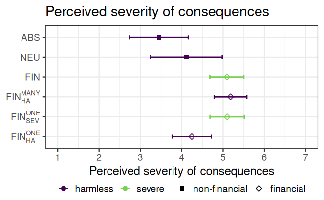

```r
1
```

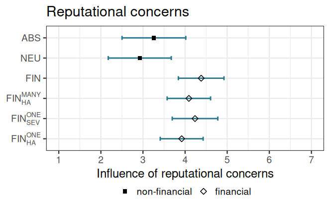

```r
tt_pf %>%
  group_by(treatment1) %>%
  summarise(Reputation = mean(reputation),
            Reputationmax = CI(reputation)[1],
            Reputationmin = CI(reputation)[3]) %>%
  mutate(financialtreat = factor(ifelse(grepl("fin", treatment1), 1, 0))) %>%
  ggplot(aes(x = treatment1,
             y = Reputation,
             ymax = Reputationmax,
             ymin = Reputationmin,
             shape = financialtreat)) +
  geom_errorbar(width=.2, lwd = 1, color = viridis(n = 6)[3]) +
  geom_point(lwd = 2.7) +
  coord_flip() +
  theme_bw(base_size = 18) +
  theme(legend.position="bottom",
        legend.title = element_blank(),
        legend.background = element_blank(),
        legend.margin = margin(t = 0),
        legend.box.margin = margin(t = 0),
        legend.box.spacing = unit(0.3, "cm"),
        axis.title.y = element_blank(),
        panel.grid.minor.y = element_blank()) +
  scale_x_discrete(labels = rev(c(expression(ABS),
                                  expression(NEU),
                                  expression(FIN),
                                  expression(FIN[HA]^MANY),
                                  expression(FIN[SEV]^ONE),
                                  expression(FIN[HA]^ONE)))) +
  scale_shape_manual(values = c(15, 5),
                     labels = c("non-financial", "financial")) +
  scale_y_continuous(limits = c(1, 7),
                     breaks = seq(1, 7, 1)) +
  ylab("Influence of reputational concerns") +
  labs(title = "Reputational concerns")
ggsave("../git_latex/graphs/ReputationalConcerns.pdf", width=20, height=15, units="cm")
```

## Figure B1

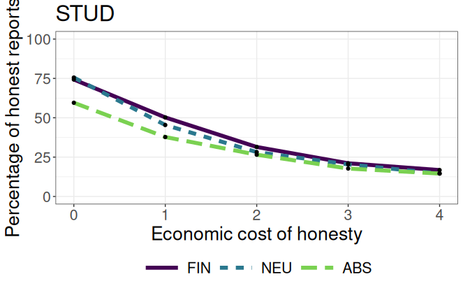

```r
tt_stud_reshaped$treatment1 <- factor(tt_stud_reshaped$treatment, levels = c('sh_sev_fin', 'su_ha_neu', 'su_ha_abs'))
options(repr.plot.width  = 8,
        repr.plot.height = 6)
ggplot(tt_stud_reshaped %>%
         filter(question=="belief") %>%
         mutate(cost = as.numeric(cost) * (-1) + 5) %>%
         group_by(cost, treatment1) %>%
         summarise(belief=100 - mean(choice)),
       aes(x=cost, y=belief, group=treatment1)) +
  geom_line(aes(color=treatment1, linetype=treatment1), size=2) +
  geom_point() +
  labs(x="Economic cost of honesty",
       y="Percentage of honest reports") +
  theme_bw() +
  theme(text = element_text(size = 20)) +
  theme(legend.position="bottom",
        legend.key.width = unit(3, "line"),
        legend.title = element_blank(),
        panel.grid.minor.x = element_blank()) +
  scale_linetype_discrete(guide = 'legend', name="Treatment",
                          labels = c(expression(FIN),
                                     expression(NEU),
                                     expression(ABS))) +
  scale_color_manual(guide = 'legend', name="Treatment", values=viridis(n = 6)[c(1, 3, 5)],
                     labels = c(expression(FIN),
                                expression(NEU),
                                expression(ABS))) +
  ylim(0, 100) +
  labs(title = "STUD")
ggsave("../git_data/graphs/BeliefsPercLies_STUD.pdf", width=20, height=15, units="cm")
```

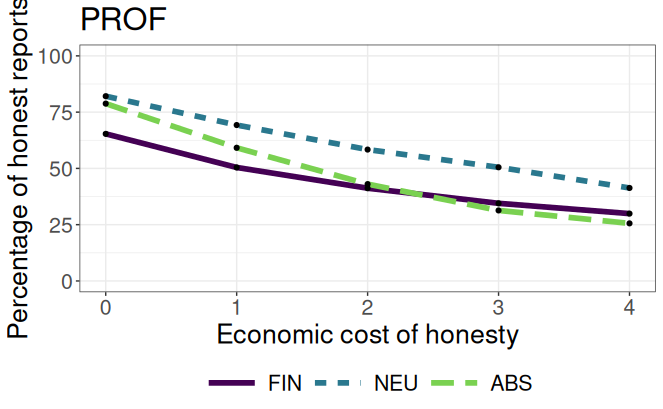

```r
tt_before_reshaped$treatment1 <- factor(tt_before_reshaped$treatment, levels = c('sh_sev_fin', 'sh_ha_fin', 'su_ha_neu',
                                                                         'su_sev_fin', 'su_ha_abs', 'su_ha_fin'))
tt_pf_reshaped$treatment1 <- factor(tt_pf_reshaped$treatment, levels = c('sh_sev_fin', 'sh_ha_fin', 'su_ha_neu',
                                                                         'su_sev_fin', 'su_ha_abs', 'su_ha_fin'))
options(repr.plot.width  = 8,
        repr.plot.height = 6)
ggplot(rbind(tt_before_reshaped, tt_pf_reshaped) %>%
         filter(question=="belief",
                treatment=="su_ha_neu"|treatment=="su_ha_abs"|treatment=="sh_sev_fin") %>%
         mutate(cost = as.numeric(cost) * (-1) + 5) %>%
         group_by(cost, context) %>%
         summarise(belief=100 - mean(choice)),
       aes(x=cost, y=belief, group=context)) +
  geom_line(aes(color=context, linetype=context), size=2) +
  geom_point() +
  labs(x="Economic cost of honesty",
       y="Percentage of honest reports") +
  theme_bw() +
  theme(text = element_text(size = 20)) +
  theme(legend.position="bottom",
        legend.key.width = unit(3, "line"),
        legend.title = element_blank(),
        panel.grid.minor.x = element_blank()) +
  scale_linetype_discrete(guide = 'legend', name="Treatment",
                          labels = c(expression(FIN),
                                     expression(NEU),
                                     expression(ABS))) +
  scale_color_manual(guide = 'legend', name="Treatment", values=viridis(n = 6)[c(1, 3, 5)],
                     labels = c(expression(FIN),
                                expression(NEU),
                                expression(ABS))) +
  ylim(0, 100) +
  labs(title = "PROF")
ggsave("../git_data/graphs/BeliefsPercLies_PROF.pdf", width=20, height=15, units="cm")
```

Correlation own lying behavior/beliefs

## Figure 5

```r
normsbeliefs <- merge %>%
  filter(prof1.tt == 1) %>%
  group_by(prof.norms, treatment1, cost) %>%
  summarise(norm = mean(norm, na.rm=TRUE),
            normf = mean(norms_false, na.rm=TRUE),
            normt = mean(norms_true, na.rm=TRUE),
            choice = mean(choice, na.rm=TRUE),
            belief = mean(norms_belief, na.rm=TRUE), n())
```

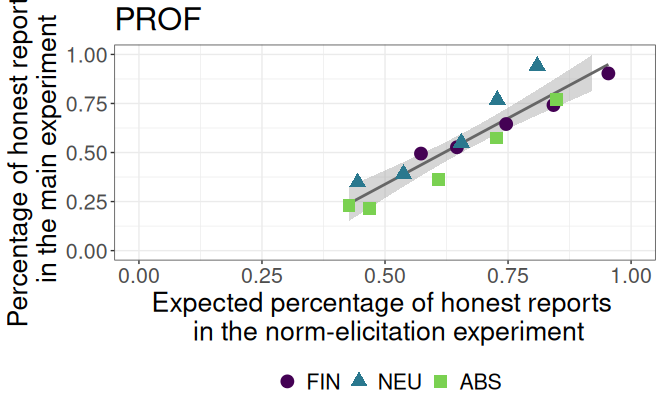

```r
normsbeliefs$treatment1 <- factor(normsbeliefs$treatment1, levels = c('sh_sev_fin', 'su_ha_neu', 'su_ha_abs'))

ggplot(normsbeliefs %>% filter(prof.norms==1), aes(x = 1 - belief, y = 1 - choice)) +
  geom_smooth(method = lm, color="grey40") +
  geom_point(aes(color = treatment1, shape = treatment1), size = 4.2) +
  labs(x="Expected percentage of honest reports \n in the norm-elicitation experiment",
       y="Percentage of honest reports \n in the main experiment") +
  theme_bw() +
  theme(text = element_text(size = 20)) +
  theme(legend.position="bottom") +
  scale_color_manual(guide = "legend", name="",
                     values=viridis(n = 6)[c(1, 3, 5)],
                     labels = c(expression(FIN),
                                expression(NEU),
                                expression(ABS))) +
  scale_shape_manual(guide = "legend", name="",
                     values = c(19, 17, 15),
                     labels = c(expression(FIN),
                                expression(NEU),
                                expression(ABS))) +
  scale_y_continuous(limits = c(0, 1), breaks=seq(0, 1, 0.25)) +
  xlim(0, 1) +
  labs(title = bquote("PROF"))
ggsave("../git_data/graphs/BeliefsPercLiesExpIExpII_PROF.pdf", width=20, height=15, units="cm")
```

```r
1 - normsbeliefs %>% filter(prof.norms==1) %>% .$belief %>% max(na.rm=TRUE)
```

```
[1] 0.426875
```

```r
normsbeliefs %>% filter(prof.norms==1) %>% filter(1 - choice < 0.426875) %>% .$choice %>% length()
```

```
[1] 5
```

```r
normsbeliefsstudprof <- merge %>%
  filter(prof.norms==2) %>%
  group_by(prof.norms, treatment1, cost) %>%
  summarise(norm = mean(norm), choice = mean(choice), beliefstudprof = mean(norms_belief)) %>%
  ungroup %>%
  dplyr::select(-starts_with("prof")) %>%
  na.omit()

normsbeliefs1 <- full_join(normsbeliefs,
                           normsbeliefsstudprof,
                           by = c("treatment1", "cost"),
                           suffix = c(".norms", ".studprof")) %>%
  na.omit()
```

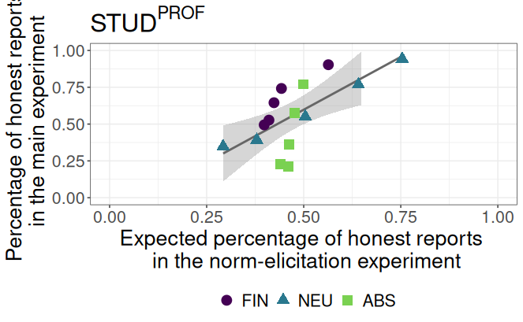

```r
normsbeliefs1$treatment1 <- factor(normsbeliefs1$treatment1, levels = c('sh_sev_fin', 'su_ha_neu', 'su_ha_abs'))

ggplot(normsbeliefs1 %>% filter(prof.norms==1), aes(x = 1 - beliefstudprof, y = 1 - choice.norms)) +
  geom_smooth(method = lm, color="grey40") +
  geom_point(aes(color = treatment1, shape = treatment1), size = 4.2) +
  labs(x="Expected percentage of honest reports \n in the norm-elicitation experiment",
       y="Percentage of honest reports \n in the main experiment") +
  theme_bw() +
  theme(text = element_text(size = 20)) +
  theme(legend.position="bottom") +
  scale_color_manual(guide = "legend", name="",
                     values=viridis(n = 6)[c(1, 3, 5)],
                     labels = c(expression(FIN),
                                expression(NEU),
                                expression(ABS))) +
  scale_shape_manual(guide = "legend", name="",
                     values = c(19, 17, 15),
                     labels = c(expression(FIN),
                                expression(NEU),
                                expression(ABS))) +
  scale_y_continuous(limits = c(0, 1), breaks=seq(0, 1, 0.25)) +
  xlim(0, 1) +
  labs(title = bquote("STUD"^"PROF"))
ggsave("../git_data/graphs/BeliefsPercLiesExpIExpII_STUDPROF.pdf", width=20, height=15, units="cm")
```

## Table B8

```r
regbeliefsexpIexpII_stud <- lm(choice ~ belief, data = normsbeliefs %>% filter(prof.norms==0))
regbeliefsexpIexpII_prof <- lm(choice ~ belief, data = normsbeliefs %>% filter(prof.norms==1))
regbeliefsexpIexpII_studprof <- lm(choice.norms ~ beliefstudprof, data = normsbeliefs1 %>% filter(prof.norms==1))

stargazer(regbeliefsexpIexpII_prof, regbeliefsexpIexpII_studprof, regbeliefsexpIexpII_stud, type = "text", digits=3)
```

[output not shown]

```r
linearHypothesis(regbeliefsexpIexpII_prof, "belief = 1")
```

```
Linear hypothesis test:
belief = 1

Model 1: restricted model
Model 2: choice ~ belief

  Res.Df      RSS Df Sum of Sq      F  Pr(>F)
1     14 0.138092
2     13 0.095514  1  0.042578 5.7951 0.03165 *
---
Signif. codes:  0 ‘***’ 0.001 ‘**’ 0.01 ‘*’ 0.05 ‘.’ 0.1 ‘ ’ 1
```

## Subject-group differences in social norms

```r
# Wilcoxon rank sum test: STUD vs. PROF for ABSTRACT
wilcox.test(norms_false ~ prof, data = norms %>% filter(prof!=2, context=="abstract"))
```

```
    Wilcoxon rank sum test with continuity correction

data:  norms_false by prof
W = 302, p-value = 0.0001985
alternative hypothesis: true location shift is not equal to 0
```

```r
# Wilcoxon rank sum test: STUD vs. PROF for NEUTRAL
wilcox.test(norms_false ~ prof, data = norms %>% filter(prof!=2, context=="neutral"))
```

```
    Wilcoxon rank sum test with continuity correction

data:  norms_false by prof
W = 307, p-value = 0.0433
alternative hypothesis: true location shift is not equal to 0
```

```r
# Wilcoxon rank sum test: STUD vs. PROF for FINANCIAL
wilcox.test(norms_false ~ prof, data = norms %>% filter(prof!=2, context=="financial"))
```

```
    Wilcoxon rank sum test with continuity correction

data:  norms_false by prof
W = 230.5, p-value = 0.0002023
alternative hypothesis: true location shift is not equal to 0
```

```r
# Wilcoxon rank sum test: neutral vs. financial
wilcox.test(norms_true ~ prof, data = norms %>% filter(prof!=2, context=="abstract"))
```

```
    Wilcoxon rank sum test with continuity correction

data:  norms_true by prof
W = 120, p-value = 0.09853
alternative hypothesis: true location shift is not equal to 0
```

```r
# Wilcoxon rank sum test: abstract vs. financial
wilcox.test(norms_true ~ prof, data = norms %>% filter(prof!=2, context=="neutral"))
```

```
    Wilcoxon rank sum test with continuity correction

data:  norms_true by prof
W = 268.5, p-value = 0.2499
alternative hypothesis: true location shift is not equal to 0
```

```r
# Wilcoxon rank sum test: abstract vs. neutral
wilcox.test(norms_true ~ prof, data = norms %>% filter(prof!=2, context=="financial"))
```

```
    Wilcoxon rank sum test with continuity correction

data:  norms_true by prof
W = 71.5, p-value = 0.02836
alternative hypothesis: true location shift is not equal to 0
```

```r
# Kruskal-Wallis test:
kruskal.test(norms_true ~ prof, data = norms)
```

```
    Kruskal-Wallis rank sum test

data:  norms_true by prof
Kruskal-Wallis chi-squared = 1.326, df = 2, p-value = 0.5153
```

## Treatment differences in social norms

```r
# Wilcoxon rank sum test: abstract vs. neutral
wilcox.test(norms_false ~ context, data = norms %>% filter(prof==1, context!="financial"))
```

```
    Wilcoxon rank sum test with continuity correction

data:  norms_false by context
W = 98.5, p-value = 0.2661
alternative hypothesis: true location shift is not equal to 0
```

```r
# Wilcoxon rank sum test: abstract vs. financial
wilcox.test(norms_false ~ context, data = norms %>% filter(prof==1, context!="neutral"))
```

```
    Wilcoxon rank sum test with continuity correction

data:  norms_false by context
W = 155.5, p-value = 0.02135
alternative hypothesis: true location shift is not equal to 0
```

```r
# Wilcoxon rank sum test: neutral vs. financial
wilcox.test(norms_false ~ context, data = norms %>% filter(prof==1, context!="abstract"))
```

```
    Wilcoxon rank sum test with continuity correction

data:  norms_false by context
W = 32.5, p-value = 0.001519
alternative hypothesis: true location shift is not equal to 0
```

## Variation across economic costs of honesty

Correlation between economic costs of honesty and social appropriateness of an *honest* report:

```r
cor.test(reshaped_norms$cost, reshaped_norms$norms_true)
```

```
    Pearson's product-moment correlation

data:  reshaped_norms$cost and reshaped_norms$norms_true
t = 1.2357, df = 913, p-value = 0.2169
alternative hypothesis: true correlation is not equal to 0
95 percent confidence interval:
 -0.02401338  0.10539096
sample estimates:
       cor
0.04086013
```

Correlation between economic costs of honesty and social appropriateness of a *dishonest* report:

```r
cor.test(reshaped_norms$cost, reshaped_norms$norms_false)
```

```
    Pearson's product-moment correlation

data:  reshaped_norms$cost and reshaped_norms$norms_false
t = -0.37549, df = 913, p-value = 0.7074
alternative hypothesis: true correlation is not equal to 0
95 percent confidence interval:
 -0.07717368  0.05242623
sample estimates:
        cor
-0.01242591
```

## Figure 4

```r
gathered <- norms %>%
  gather(key = "truefalse", value = "norms", c(norms_true, norms_false))
gathered$context1 <- factor(gathered$context, levels = c('abstract', 'neutral', 'financial'))
```

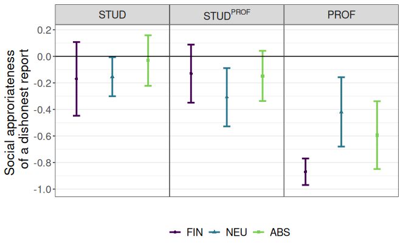

```r
gathered$treatment1 <- factor(gathered$context,
                              levels = c('financial', 'neutral', 'abstract'),
                              labels = c(expression(FIN[SEV]^MANY),
                                         expression(NEU[HA]^ONE),
                                         expression(ABS[HA]^ONE)))

ggplot(data = gathered %>%
         ungroup %>%
         mutate(prof1 = ifelse(prof==2, 0.5, prof),
                prof1 = factor(prof1,
                               levels = c(0, 0.5, 1),
                               labels = c("STUD",
                                          bquote("STUD"^"PROF"),
                                          "PROF"))) %>%
         filter(truefalse == "norms_false") %>%
         group_by(prof1, treatment1) %>%
         summarise(normsmax = CI(norms)[1],
                   normsmin = CI(norms)[3],
                   norms = mean(norms)),
       aes(x = factor(treatment1), y = norms,
           ymin = normsmin, ymax = normsmax,
           color=factor(treatment1), shape=factor(treatment1))) +
  geom_errorbar(width=.2, lwd = 1) +
  geom_point(lwd = 2.7) +
  facet_wrap( ~ prof1, labeller = label_parsed) +
  geom_hline(yintercept = 0) +
  labs(x="",
       y="Social approriateness \n of a dishonest report") +
  theme_bw() +
  theme(text = element_text(size = 16)) +
  theme(legend.position="bottom") +
  theme(axis.text.x=element_blank()) +
  theme(panel.spacing = unit(0, "lines")) +
  scale_x_discrete(breaks = NULL) +
  scale_y_continuous(breaks = scales::pretty_breaks(n = 6), limits = c(-1, 0.18)) +
  scale_color_manual(guide="legend",
                     name="",
                     values=viridis(n = 6)[c(1,3,5)],
                     labels = c(expression(FIN),
                                         expression(NEU),
                                         expression(ABS))) +
  scale_shape_discrete(guide="legend",
                       name="",
                       labels = c(expression(FIN),
                                         expression(NEU),
                                         expression(ABS)))
ggsave("../git_latex/graphs/Norms_lineplot.pdf", width=25, height=15, units="cm")
```

# Variable descriptions

| Variable | Description |
| --- | --- |
| `subject` | Subject ID |
| `payoff` | Payout from the experiment |
| `session` | Experimental session ID |
| `context` | Treatment (context, framed instructions): `abstract`, `neutral`, or `financial` |
| `order` | Ascending or decreasing order of decisions (randomly drawn for each subject) |
| `choice1` | Choice in decision 1: `0` (honest report) or `1` (dishonest report) |
| `choice2` | Choice in decision 2: `0` (honest report) or `1` (dishonest report) |
| `choice3` | Choice in decision 3: `0` (honest report) or `1` (dishonest report) |
| `choice4` | Choice in decision 4: `0` (honest report) or `1` (dishonest report) |
| `choice5` | Choice in decision 5: `0` (honest report) or `1` (dishonest report) |
| `belief1` | Expected percentage of dishonest reports in decision 1 |
| `belief2` | Expected percentage of dishonest reports in decision 2 |
| `belief3` | Expected percentage of dishonest reports in decision 3 |
| `belief4` | Expected percentage of dishonest reports in decision 4 |
| `belief5` | Expected percentage of dishonest reports in decision 5 |
| `risk` | Risk preferences elicited with the general risk question, `1` (…) to `7` (…) |
| `pref1_1` | Patience (Falk et al., 2018): `1` (completely unwilling to do so) to `7` (very willing to do so) |
| `pref1_2` | Negative Reciprocity 1 (Falk et al., 2018): `1` (completely unwilling to do so) to `7` (very willing to do so) |
| `pref1_3` | Negative Reciprocity 2 (Falk et al., 2018): `1` (completely unwilling to do so) to `7` (very willing to do so) |
| `pref1_4` | Altruism (Falk et al., 2018): `1` (completely unwilling to do so) to `7` (very willing to do so) |
| `pref2_1` | Positive Reciprocity (Falk et al., 2018): `1` (does not describe me at all) to `7` (describes me perfectly) |
| `pref2_2` | Negative Reciprocity 3 (Falk et al., 2018): `1` (does not describe me at all) to `7` (describes me perfectly) |
| `pref2_3` | Trust (Falk et al., 2018): `1` (does not describe me at all) to `7` (describes me perfectly) |
| `age` | Age |
| `female` | Gender: `0` (male) or `1` (female) |
| `education` | Education: `0` (Compulsory school), `1` (Apprenticeship), `2` (Technical college), `3` (High school), `4` (University), or `-1` (Prefer not to say) |
| `job` | Job (only PROF): `0` (Portfolio Manager), `1` (Research Analyst), `2` (Consultant), `3` (Financial Advisor), `4` (Chief-Level Executive), `5` (Trader), `6` (Fund Manager), `7` (Investment Managent), o… |
| `investment` | Investment in financial products in the last 5 years: yes (`1`) or no (`0`) |
| `whichinvestment` | If `investment = 1`, which financial product |
| `finnews` | Check financial news: `4` (Daily), `3` (Several times a week), `2` (Once a week), `1` (Less than once a week), or `0` (Never) |
| `tt` | Truth-telling task (`1`) or norm-elicitation task (`0`) |
| `word1` | Answer to word scarambling 1 |
| `word2` | Answer to word scarambling 2 |
| `word3` | Answer to word scarambling 3 |
| `word4` | Answer to word scarambling 4 |
| `word5` | Answer to word scarambling 5 |
| `word6` | Answer to word scarambling 6 |
| `word1f` | Financial word in word scrambing 1: yes (`1`) or no (`0`) |
| `word3f` | Financial word in word scrambing 3: yes (`1`) or no (`0`) |
| `word4f` | Financial word in word scrambing 4: yes (`1`) or no (`0`) |
| `word6f` | Financial word in word scrambing 6: yes (`1`) or no (`0`) |
| `wordsf` | Sum of financial words in word scramblings 1, 3, 4, and 6 |
| `lies` | Number of dishonest reports in decisions 1 through 5 |
| `beliefs` | Expected number of dishonest reports in decisions 1 through 5 |
| `prof` | Subject group: `0` (STUD), `1` (PROF), or `2` (STUDPROF) |
| `norms_true1` | Social appropriateness assessment of an honest report in decision 1 |
| `norms_false1` | Social appropriateness assessment of a dishonest report in decision 1 |
| `norms_true2` | Social appropriateness assessment of an honest report in decision 2 |
| `norms_false2` | Social appropriateness assessment of a dishonest report in decision 2 |
| `norms_true3` | Social appropriateness assessment of an honest report in decision 3 |
| `norms_false3` | Social appropriateness assessment of a dishonest report in decision 3 |
| `norms_true4` | Social appropriateness assessment of an honest report in decision 4 |
| `norms_false5` | Social appropriateness assessment of a dishonest report in decision 4 |
| `norms_true5` | Social appropriateness assessment of an honest report in decision 5 |
| `norms_false5` | Social appropriateness assessment of a dishonest report in decision 5 |
| `norms_true` | Average social appropriateness assessment of an honest report |
| `norms_false` | Average social appropriateness assessment of a dishonest report |